[Jeffery Shih-Chieh Wang](https://jeffery-wang.com/)

# Accelerator Crash Course - R

Center of Excellence for Women & Technology, Indiana University Bloomington

Author

Jeffery (Shih-Chieh) Wang

Published

April 11, 2026

# Course Overview

- **Learning materials:** jeffery-wang.com/r-basics/
- **Duration:** 4 hours (10:30–12:00; 13:00-15:30)
- **Goal**: By the end of this course, you will know the basics of R, able to import data into R, maniupate and tidy data sets using tidyverse tool, create visualizations, and get a better idea how to use generative AI to accelerate the R learning.
- **Prerequisites:** None! This course is designed for true beginners.
- **What you need:**
  - A laptop with R and RStudio installed
  - An internet connection (for installing packages and AI tools)

## Schedule

**10:30–11:30**  
Module 1: Getting Started with R & RStudio

**11:30–12:00**  
Module 2: Importing Data (readr & readxl)

**12:00–1:00**  
*Lunch Break*

**13:00–14:00**  
Module 3: Data Manipulation with dplyr

**14:00-15:30**  
Module 4: Data Tidying with tidyr  
Module 5: Visualization with Base R  
Module 6: Leveraging AI

# 1 Module 1: Getting Started

## 1.1 Learning Objectives

- Navigate the RStudio interface (console, script editor, environment, files)
- Understand basic R concepts: objects, assignment, data types
- Install and load packages
- Understand what the tidyverse is

## 1.2 The RStudio Interface

RStudio is the most popular IDE for R language. It has four main panes:

- `IDE: Integrated Development Environment (code editing, building, testing, debugging, and many others)`
1. **Source Editor** (top-left) — where you write and save scripts
2. **Console** (bottom-left) — where R runs commands
3. **Environment** (top-right) — shows your data and objects
4. **Files/Plots/Help** (bottom-right) — file browser, plot viewer, documentation
- Note: You may customize the layout by going to `Tools` → `Global Options`→ `Pane Layout`

## 1.3 R Basics

### 1.3.1 Basic Calculations in R

- One of the easiest ways to start using R is to treat it like a calculator.
- R can perform basic arithmetic operations such as addition, subtraction, multiplication, division, and exponents.

```r
# Some examples:

2 + 3        # addition
```

```
[1] 5
```

```r
10 - 4       # subtraction
```

```
[1] 6
```

```r
6 * 5        # multiplication
```

```
[1] 30
```

```r
12 / 3       # division
```

```
[1] 4
```

```r
2^3          # exponent
```

```
[1] 8
```

```r
(2 + 3) * 4  # parentheses change the order of operations
```

```
[1] 20
```

### 1.3.2 Common R Objects

Objects are the basic building blocks for storing data in R. Five common types of R objects are vectors, factors, matrices, lists, and data frames.

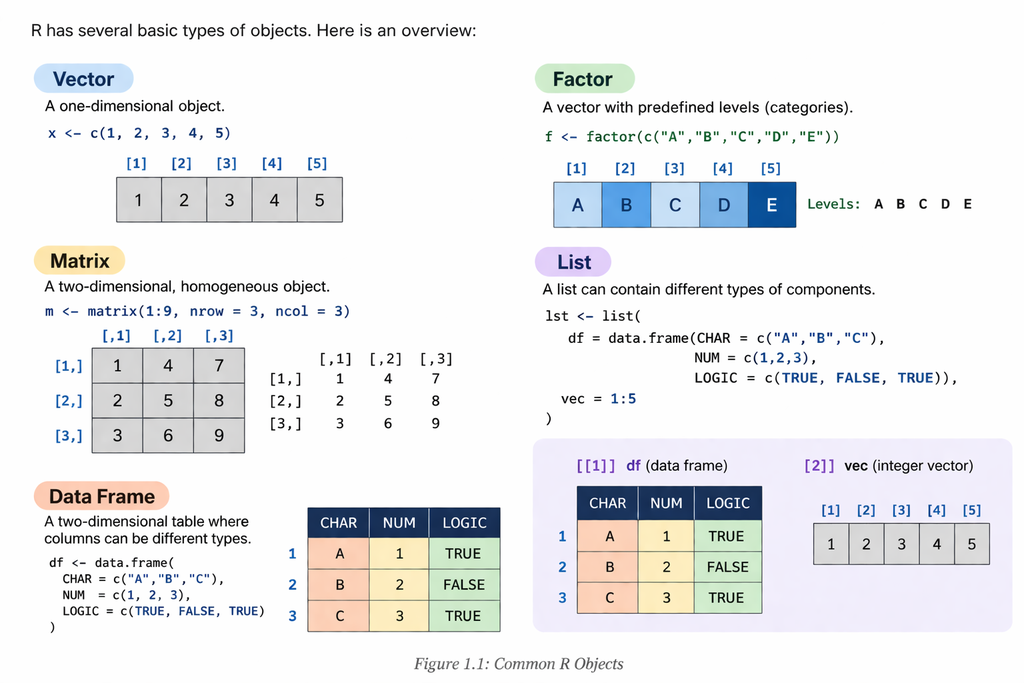

```r
# Assignment: use <- to store values in objects
my_name <- "World"
my_number <- 42

# Print values
my_name
```

```
[1] "World"
```

```r
my_number
```

```
[1] 42
```

```r
# Vectors: a collection of values of the same type
ages <- c(25, 30, 35, 40, 45)
names <- c("Alice", "Bob", "Carol", "Dave", "Eve")

# Basic operations on vectors
mean(ages)
```

```
[1] 35
```

```r
length(ages)
```

```
[1] 5
```

```r
# Basic data types
class(my_name)    # character
```

```
[1] "character"
```

```r
class(my_number)  # numeric
```

```
[1] "numeric"
```

```r
class(1)          #
```

```
[1] "numeric"
```

```r
class(TRUE)       # logical (can be )
```

```
[1] "logical"
```

```r
# Example about checking logical values
is_adult <- 20 >= 18
class(is_adult)   # logical
```

```
[1] "logical"
```

```r
is_adult          # TRUE, because it stores the result of "20 >= 18"
```

```
[1] TRUE
```

```r
is_tall <- 150 > 180
is_tall
```

```
[1] FALSE
```

### 1.3.3 Installing and Loading the Tidyverse

```r
# Install the tidyverse (only need to do this once)
install.packages("tidyverse")
```

```r
# Load the tidyverse (do this every session)
library(tidyverse)
```

The tidyverse is a collection of packages that share a common design philosophy:

- **readr** — reading data files (CSV, TSV, etc.)
- **dplyr** — data manipulation (filter, select, mutate, summarize)
- **tidyr** — reshaping and tidying data
- **ggplot2** — data visualization
- **stringr** — string manipulation
- **forcats** — working with categorical data (factors)
- **purrr** — functional programming
- **tibble** — modern data frames

### 1.3.4 Data Frame?

```r
# A data frame is a table — the fundamental data structure for analysis
# Let's look at a built-in dataset in ggplot2 (part of the idyverse)
mpg
```

```
# A tibble: 234 × 11
   manufacturer model      displ  year   cyl trans drv     cty   hwy fl    class
   <chr>        <chr>      <dbl> <int> <int> <chr> <chr> <int> <int> <chr> <chr>
 1 audi         a4           1.8  1999     4 auto… f        18    29 p     comp…
 2 audi         a4           1.8  1999     4 manu… f        21    29 p     comp…
 3 audi         a4           2    2008     4 manu… f        20    31 p     comp…
 4 audi         a4           2    2008     4 auto… f        21    30 p     comp…
 5 audi         a4           2.8  1999     6 auto… f        16    26 p     comp…
 6 audi         a4           2.8  1999     6 manu… f        18    26 p     comp…
 7 audi         a4           3.1  2008     6 auto… f        18    27 p     comp…
 8 audi         a4 quattro   1.8  1999     4 manu… 4        18    26 p     comp…
 9 audi         a4 quattro   1.8  1999     4 auto… 4        16    25 p     comp…
10 audi         a4 quattro   2    2008     4 manu… 4        20    28 p     comp…
# ℹ 224 more rows
```

```r
# Useful functions for exploring data frames
dim(mpg)       # rows x columns
```

```
[1] 234  11
```

```r
names(mpg)     # column names
```

```
 [1] "manufacturer" "model"        "displ"        "year"         "cyl"
 [6] "trans"        "drv"          "cty"          "hwy"          "fl"
[11] "class"
```

```r
glimpse(mpg)   # compact overview
```

```
Rows: 234
Columns: 11
$ manufacturer <chr> "audi", "audi", "audi", "audi", "audi", "audi", "audi", "…
$ model        <chr> "a4", "a4", "a4", "a4", "a4", "a4", "a4", "a4 quattro", "…
$ displ        <dbl> 1.8, 1.8, 2.0, 2.0, 2.8, 2.8, 3.1, 1.8, 1.8, 2.0, 2.0, 2.…
$ year         <int> 1999, 1999, 2008, 2008, 1999, 1999, 2008, 1999, 1999, 200…
$ cyl          <int> 4, 4, 4, 4, 6, 6, 6, 4, 4, 4, 4, 6, 6, 6, 6, 6, 6, 8, 8, …
$ trans        <chr> "auto(l5)", "manual(m5)", "manual(m6)", "auto(av)", "auto…
$ drv          <chr> "f", "f", "f", "f", "f", "f", "f", "4", "4", "4", "4", "4…
$ cty          <int> 18, 21, 20, 21, 16, 18, 18, 18, 16, 20, 19, 15, 17, 17, 1…
$ hwy          <int> 29, 29, 31, 30, 26, 26, 27, 26, 25, 28, 27, 25, 25, 25, 2…
$ fl           <chr> "p", "p", "p", "p", "p", "p", "p", "p", "p", "p", "p", "p…
$ class        <chr> "compact", "compact", "compact", "compact", "compact", "c…
```

```r
head(mpg)      # first 6 rows
```

```
# A tibble: 6 × 11
  manufacturer model displ  year   cyl trans      drv     cty   hwy fl    class
  <chr>        <chr> <dbl> <int> <int> <chr>      <chr> <int> <int> <chr> <chr>
1 audi         a4      1.8  1999     4 auto(l5)   f        18    29 p     compa…
2 audi         a4      1.8  1999     4 manual(m5) f        21    29 p     compa…
3 audi         a4      2    2008     4 manual(m6) f        20    31 p     compa…
4 audi         a4      2    2008     4 auto(av)   f        21    30 p     compa…
5 audi         a4      2.8  1999     6 auto(l5)   f        16    26 p     compa…
6 audi         a4      2.8  1999     6 manual(m5) f        18    26 p     compa…
```

- Another approach more common because you most like import your own data

```r
# use vector
data_mpg <- mpg
glimpse(data_mpg )   # compact overview
```

```
Rows: 234
Columns: 11
$ manufacturer <chr> "audi", "audi", "audi", "audi", "audi", "audi", "audi", "…
$ model        <chr> "a4", "a4", "a4", "a4", "a4", "a4", "a4", "a4 quattro", "…
$ displ        <dbl> 1.8, 1.8, 2.0, 2.0, 2.8, 2.8, 3.1, 1.8, 1.8, 2.0, 2.0, 2.…
$ year         <int> 1999, 1999, 2008, 2008, 1999, 1999, 2008, 1999, 1999, 200…
$ cyl          <int> 4, 4, 4, 4, 6, 6, 6, 4, 4, 4, 4, 6, 6, 6, 6, 6, 6, 8, 8, …
$ trans        <chr> "auto(l5)", "manual(m5)", "manual(m6)", "auto(av)", "auto…
$ drv          <chr> "f", "f", "f", "f", "f", "f", "f", "4", "4", "4", "4", "4…
$ cty          <int> 18, 21, 20, 21, 16, 18, 18, 18, 16, 20, 19, 15, 17, 17, 1…
$ hwy          <int> 29, 29, 31, 30, 26, 26, 27, 26, 25, 28, 27, 25, 25, 25, 2…
$ fl           <chr> "p", "p", "p", "p", "p", "p", "p", "p", "p", "p", "p", "p…
$ class        <chr> "compact", "compact", "compact", "compact", "compact", "c…
```

```r
summary(data_mpg)   # summarize your data variables (basic stats, types, NAs)
```

```
 manufacturer          model               displ            year
 Length:234         Length:234         Min.   :1.600   Min.   :1999
 Class :character   Class :character   1st Qu.:2.400   1st Qu.:1999
 Mode  :character   Mode  :character   Median :3.300   Median :2004
                                       Mean   :3.472   Mean   :2004
                                       3rd Qu.:4.600   3rd Qu.:2008
                                       Max.   :7.000   Max.   :2008
      cyl           trans               drv                 cty
 Min.   :4.000   Length:234         Length:234         Min.   : 9.00
 1st Qu.:4.000   Class :character   Class :character   1st Qu.:14.00
 Median :6.000   Mode  :character   Mode  :character   Median :17.00
 Mean   :5.889                                         Mean   :16.86
 3rd Qu.:8.000                                         3rd Qu.:19.00
 Max.   :8.000                                         Max.   :35.00
      hwy             fl               class
 Min.   :12.00   Length:234         Length:234
 1st Qu.:18.00   Class :character   Class :character
 Median :24.00   Mode  :character   Mode  :character
 Mean   :23.44
 3rd Qu.:27.00
 Max.   :44.00
```

```r
dim(data_mpg )       # rows x columns
```

```
[1] 234  11
```

```r
names(data_mpg )     # column names
```

```
 [1] "manufacturer" "model"        "displ"        "year"         "cyl"
 [6] "trans"        "drv"          "cty"          "hwy"          "fl"
[11] "class"
```

```r
head(data_mpg)      # first 6 rows
```

```
# A tibble: 6 × 11
  manufacturer model displ  year   cyl trans      drv     cty   hwy fl    class
  <chr>        <chr> <dbl> <int> <int> <chr>      <chr> <int> <int> <chr> <chr>
1 audi         a4      1.8  1999     4 auto(l5)   f        18    29 p     compa…
2 audi         a4      1.8  1999     4 manual(m5) f        21    29 p     compa…
3 audi         a4      2    2008     4 manual(m6) f        20    31 p     compa…
4 audi         a4      2    2008     4 auto(av)   f        21    30 p     compa…
5 audi         a4      2.8  1999     6 auto(l5)   f        16    26 p     compa…
6 audi         a4      2.8  1999     6 manual(m5) f        18    26 p     compa…
```

```r
# Let's see the car company list
length(data_mpg$manufacturer)
```

```
[1] 234
```

```r
unique(data_mpg$manufacturer)
```

```
 [1] "audi"       "chevrolet"  "dodge"      "ford"       "honda"
 [6] "hyundai"    "jeep"       "land rover" "lincoln"    "mercury"
[11] "nissan"     "pontiac"    "subaru"     "toyota"     "volkswagen"
```

```r
length(unique((data_mpg$manufacturer)))
```

```
[1] 15
```

```r
# And all the car models
unique(data_mpg$model)
```

```
 [1] "a4"                     "a4 quattro"             "a6 quattro"
 [4] "c1500 suburban 2wd"     "corvette"               "k1500 tahoe 4wd"
 [7] "malibu"                 "caravan 2wd"            "dakota pickup 4wd"
[10] "durango 4wd"            "ram 1500 pickup 4wd"    "expedition 2wd"
[13] "explorer 4wd"           "f150 pickup 4wd"        "mustang"
[16] "civic"                  "sonata"                 "tiburon"
[19] "grand cherokee 4wd"     "range rover"            "navigator 2wd"
[22] "mountaineer 4wd"        "altima"                 "maxima"
[25] "pathfinder 4wd"         "grand prix"             "forester awd"
[28] "impreza awd"            "4runner 4wd"            "camry"
[31] "camry solara"           "corolla"                "land cruiser wagon 4wd"
[34] "toyota tacoma 4wd"      "gti"                    "jetta"
[37] "new beetle"             "passat"
```

```r
sort(unique(data_mpg$model))
```

```
 [1] "4runner 4wd"            "a4"                     "a4 quattro"
 [4] "a6 quattro"             "altima"                 "c1500 suburban 2wd"
 [7] "camry"                  "camry solara"           "caravan 2wd"
[10] "civic"                  "corolla"                "corvette"
[13] "dakota pickup 4wd"      "durango 4wd"            "expedition 2wd"
[16] "explorer 4wd"           "f150 pickup 4wd"        "forester awd"
[19] "grand cherokee 4wd"     "grand prix"             "gti"
[22] "impreza awd"            "jetta"                  "k1500 tahoe 4wd"
[25] "land cruiser wagon 4wd" "malibu"                 "maxima"
[28] "mountaineer 4wd"        "mustang"                "navigator 2wd"
[31] "new beetle"             "passat"                 "pathfinder 4wd"
[34] "ram 1500 pickup 4wd"    "range rover"            "sonata"
[37] "tiburon"                "toyota tacoma 4wd"
```

- `dbl: double-precision floating-point numbers, storing real numbers for those with decimal points`
- Tibble (modern) vs Dataframe

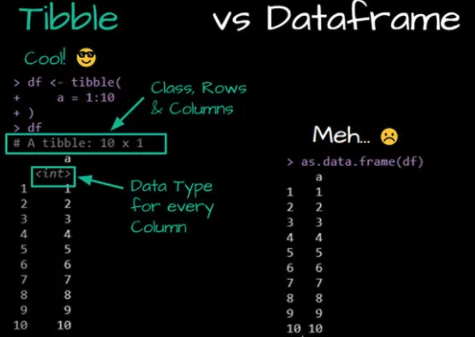

- Source: [www.r-bloggers.com](https://www.r-bloggers.com/2021/02/4-ways-to-make-data-frames-in-r/)

## 1.4 Exercise 1.1

```r
# 1. Create a vector called 'fruits' containing: "apple", "banana", "cherry"
# 2. Create a vector called 'prices' with values: 1.20, 0.50, 2.75
# 3. Find the mean price
```

## 1.5 Exercise 1.2

```r
# 1. Load the tidyverse and explore the 'diamonds' dataset using glimpse()

# 2. How many rows and columns?

# 3. What are the variable names?

# 4  What does 'cut' contain?
```

# 2 Module 2: Importing Data

## 2.1 Learning Objectives

- Read CSV files into R with `read_csv()`
- Understand file paths and working directories
- Inspect imported data for issues
- Know about other import functions (Excel, TSV, etc.)

## 2.2 Key Concepts

### 2.2.1 Your Working Directory

```r
# Where is R looking for files?
getwd()

# You can set it in RStudio: Session > Set Working Directory > Choose Directory

# Or use code:
setwd("/path/to/your/folder") # Replace the path with the actual location of your file

list.files()
```

### 2.2.2 Reading CSV Files

```r
# Reading a CSV file
# Replace the path with the actual location of your file
survey_data <- read_csv("sample_survey_data.csv")

# Look at the result
survey_data
```

```
# A tibble: 40 × 10
   respondent_id   age gender department  years_experience satisfaction_score
           <dbl> <dbl> <chr>  <chr>                  <dbl>              <dbl>
 1             1    28 Female Marketing                  3                4.2
 2             2    35 Male   Engineering                8                3.8
 3             3    42 Female Engineering               15                4.5
 4             4    25 Male   Sales                      1                3.2
 5             5    31 Female Marketing                  5                4
 6             6    38 Male   HR                        10                3.5
 7             7    29 Female Engineering                4                4.3
 8             8    45 Male   Sales                     18                3.9
 9             9    33 Female HR                         7                4.1
10            10    27 Male   Marketing                  2                3.6
# ℹ 30 more rows
# ℹ 4 more variables: monthly_hours <dbl>, remote_days_per_week <dbl>,
#   training_completed <lgl>, annual_salary <dbl>
```

```r
glimpse(survey_data)
```

```
Rows: 40
Columns: 10
$ respondent_id        <dbl> 1, 2, 3, 4, 5, 6, 7, 8, 9, 10, 11, 12, 13, 14, 15…
$ age                  <dbl> 28, 35, 42, 25, 31, 38, 29, 45, 33, 27, 40, 36, 2…
$ gender               <chr> "Female", "Male", "Female", "Male", "Female", "Ma…
$ department           <chr> "Marketing", "Engineering", "Engineering", "Sales…
$ years_experience     <dbl> 3, 8, 15, 1, 5, 10, 4, 18, 7, 2, 12, 9, 1, 22, 4,…
$ satisfaction_score   <dbl> 4.2, 3.8, 4.5, 3.2, 4.0, 3.5, 4.3, 3.9, 4.1, 3.6,…
$ monthly_hours        <dbl> 165, 180, 170, 175, 160, 155, 185, 170, 150, 168,…
$ remote_days_per_week <dbl> 2, 3, 4, 1, 2, 3, 4, 1, 2, 2, 5, 1, 2, 3, 3, 0, 4…
$ training_completed   <lgl> TRUE, TRUE, TRUE, FALSE, TRUE, TRUE, TRUE, FALSE,…
$ annual_salary        <dbl> 52000, 85000, 105000, 45000, 58000, 72000, 78000,…
```

```r
summary(survey_data)
```

```
 respondent_id        age           gender           department
 Min.   : 1.00   Min.   :23.00   Length:40          Length:40
 1st Qu.:10.75   1st Qu.:29.00   Class :character   Class :character
 Median :20.50   Median :33.50   Mode  :character   Mode  :character
 Mean   :20.50   Mean   :34.35
 3rd Qu.:30.25   3rd Qu.:39.25
 Max.   :40.00   Max.   :50.00

 years_experience satisfaction_score monthly_hours remote_days_per_week
 Min.   : 1.000   Min.   :3.000      Min.   :144   Min.   :0.00
 1st Qu.: 3.000   1st Qu.:3.575      1st Qu.:160   1st Qu.:1.00
 Median : 6.000   Median :4.000      Median :170   Median :2.00
 Mean   : 7.541   Mean   :3.930      Mean   :169   Mean   :2.35
 3rd Qu.:10.000   3rd Qu.:4.300      3rd Qu.:179   3rd Qu.:3.00
 Max.   :22.000   Max.   :4.800      Max.   :192   Max.   :5.00
 NA's   :3                           NA's   :1
 training_completed annual_salary
 Mode :logical      Min.   : 44000
 FALSE:10           1st Qu.: 56000
 TRUE :30           Median : 66000
                    Mean   : 69189
                    3rd Qu.: 75000
                    Max.   :115000
                    NA's   :3
```

### 2.2.3 Understanding the Output

When `read_csv()` imports data, it tells you:

- How many rows and columns it found
- What type it guessed for each column (character, double, integer, etc.)

### 2.2.4 Common Import Issues

```r
# If your CSV uses semicolons instead of commas (common in Europe)
data <- read_csv2("european_file.csv")

# If your file uses tabs (Tab-Separated Values)
data <- read_delim("file.tsv", delim = "\t")

# Reading Excel files (need the readxl package)
library(readxl)
data <- read_excel("file.xlsx")
data <- read_excel("file.xlsx", sheet = "Sheet2")  # specific sheet
```

- Example of European Semicolon CSV (`read_csv2`)

  This format is the standard in many European countries where the **comma** is already used for decimals (e.g.,1,50 instead of 1.50). To separate the columns, they use a **semicolon**.

  ```
  Country;GDP_Growth;Inflation_Rate
  Germany;1,5;2,1
  France;1,2;1,8
  Italy;0,9;2,3
  ```

- Example of Tab-Separated Values

  In a “raw” view, tabs often look like big chunks of whitespace. In reality, they are a single invisible character (`\t`). TSVs are great because you almost never have a “tab” inside your actual data, so it’s less likely to break your code.

  ```
  ID  Observation Status
  101 High Pressure   Stable
  102 Low Temperature Critical
  103 Ambient Stable
  ```

### 2.2.5 Working with Built-in Datasets

```r
# R comes with many practice datasets
# The tidyverse adds even more
data(mpg)        # fuel economy data
data(diamonds)   # diamond prices
data(starwars)   # Star Wars characters

# View the starwars dataset
starwars
```

```
# A tibble: 87 × 14
   name     height  mass hair_color skin_color eye_color birth_year sex   gender
   <chr>     <int> <dbl> <chr>      <chr>      <chr>          <dbl> <chr> <chr>
 1 Luke Sk…    172    77 blond      fair       blue            19   male  mascu…
 2 C-3PO       167    75 <NA>       gold       yellow         112   none  mascu…
 3 R2-D2        96    32 <NA>       white, bl… red             33   none  mascu…
 4 Darth V…    202   136 none       white      yellow          41.9 male  mascu…
 5 Leia Or…    150    49 brown      light      brown           19   fema… femin…
 6 Owen La…    178   120 brown, gr… light      blue            52   male  mascu…
 7 Beru Wh…    165    75 brown      light      blue            47   fema… femin…
 8 R5-D4        97    32 <NA>       white, red red             NA   none  mascu…
 9 Biggs D…    183    84 black      light      brown           24   male  mascu…
10 Obi-Wan…    182    77 auburn, w… fair       blue-gray       57   male  mascu…
# ℹ 77 more rows
# ℹ 5 more variables: homeworld <chr>, species <chr>, films <list>,
#   vehicles <list>, starships <list>
```

## 2.3 Exercise 2.1

```
# 1. Download the sample_survey_data.csv file to your computer
```

- Down here: [Link](https://www.dropbox.com/scl/fi/s2eem5x1awd0kxnrof6s8/sample_survey_data.csv?rlkey=u53se53dad02ho50xd10wp3dh&dl=0)

```
# 2. Read it into R using read_csv() and save it as 'survey'
# 3. Use summary() to examine the structure
# 4. How many rows and columns does it have?
# 5. What are the column names?
# 6. What variables have missing values?
```

# 3 Module 3: Data Manipulation with dplyr

## 3.1 Learning Objectives

- Chain operations with the pipe `|>` (or `%>%`)
- Sort data with `arrange()`; Note: `sort()` is a base R function
- Select columns with `select()`
- Filter rows with `filter()`
- Create new columns with `mutate()`
- Summarize data with `summarize()` and `group_by()`

## 3.2 Key Concepts

### 3.2.1 The Pipe: `|>` (or `%>%`)

The pipe takes the output of one function and feeds it as the first argument to the next function. Think of it as “and then.”

```r
# Without the pipe (nested, hard to read)
head(arrange(filter(mpg, manufacturer == "toyota"), desc(hwy)), 5)
```

```
# A tibble: 5 × 11
  manufacturer model   displ  year   cyl trans     drv     cty   hwy fl    class
  <chr>        <chr>   <dbl> <int> <int> <chr>     <chr> <int> <int> <chr> <chr>
1 toyota       corolla   1.8  2008     4 manual(m… f        28    37 r     comp…
2 toyota       corolla   1.8  1999     4 manual(m… f        26    35 r     comp…
3 toyota       corolla   1.8  2008     4 auto(l4)  f        26    35 r     comp…
4 toyota       corolla   1.8  1999     4 auto(l4)  f        24    33 r     comp…
5 toyota       camry     2.4  2008     4 manual(m… f        21    31 r     mids…
```

```r
# With the pipe (read left to right, top to bottom)
mpg |>
  filter(manufacturer == "toyota") |>
  arrange(desc(hwy)) |>
  head(5)
```

```
# A tibble: 5 × 11
  manufacturer model   displ  year   cyl trans     drv     cty   hwy fl    class
  <chr>        <chr>   <dbl> <int> <int> <chr>     <chr> <int> <int> <chr> <chr>
1 toyota       corolla   1.8  2008     4 manual(m… f        28    37 r     comp…
2 toyota       corolla   1.8  1999     4 manual(m… f        26    35 r     comp…
3 toyota       corolla   1.8  2008     4 auto(l4)  f        26    35 r     comp…
4 toyota       corolla   1.8  1999     4 auto(l4)  f        24    33 r     comp…
5 toyota       camry     2.4  2008     4 manual(m… f        21    31 r     mids…
```

```r
# arrange() for sorting
arrange(mpg, hwy)        # hwy (highway) ascending, small to large
```

```
# A tibble: 234 × 11
   manufacturer model      displ  year   cyl trans drv     cty   hwy fl    class
   <chr>        <chr>      <dbl> <int> <int> <chr> <chr> <int> <int> <chr> <chr>
 1 dodge        dakota pi…   4.7  2008     8 auto… 4         9    12 e     pick…
 2 dodge        durango 4…   4.7  2008     8 auto… 4         9    12 e     suv
 3 dodge        ram 1500 …   4.7  2008     8 auto… 4         9    12 e     pick…
 4 dodge        ram 1500 …   4.7  2008     8 manu… 4         9    12 e     pick…
 5 jeep         grand che…   4.7  2008     8 auto… 4         9    12 e     suv
 6 chevrolet    k1500 tah…   5.3  2008     8 auto… 4        11    14 e     suv
 7 jeep         grand che…   6.1  2008     8 auto… 4        11    14 p     suv
 8 chevrolet    c1500 sub…   5.3  2008     8 auto… r        11    15 e     suv
 9 chevrolet    k1500 tah…   5.7  1999     8 auto… 4        11    15 r     suv
10 dodge        dakota pi…   5.2  1999     8 auto… 4        11    15 r     pick…
# ℹ 224 more rows
```

```r
arrange(mpg, desc(hwy))  # descending, large to small
```

```
# A tibble: 234 × 11
   manufacturer model      displ  year   cyl trans drv     cty   hwy fl    class
   <chr>        <chr>      <dbl> <int> <int> <chr> <chr> <int> <int> <chr> <chr>
 1 volkswagen   jetta        1.9  1999     4 manu… f        33    44 d     comp…
 2 volkswagen   new beetle   1.9  1999     4 manu… f        35    44 d     subc…
 3 volkswagen   new beetle   1.9  1999     4 auto… f        29    41 d     subc…
 4 toyota       corolla      1.8  2008     4 manu… f        28    37 r     comp…
 5 honda        civic        1.8  2008     4 auto… f        25    36 r     subc…
 6 honda        civic        1.8  2008     4 auto… f        24    36 c     subc…
 7 toyota       corolla      1.8  1999     4 manu… f        26    35 r     comp…
 8 toyota       corolla      1.8  2008     4 auto… f        26    35 r     comp…
 9 honda        civic        1.8  2008     4 manu… f        26    34 r     subc…
10 honda        civic        1.6  1999     4 manu… f        28    33 r     subc…
# ℹ 224 more rows
```

### 3.2.2 select() — Choose Columns

```r
names(mpg)
```

```
 [1] "manufacturer" "model"        "displ"        "year"         "cyl"
 [6] "trans"        "drv"          "cty"          "hwy"          "fl"
[11] "class"
```

```r
glimpse(mpg)
```

```
Rows: 234
Columns: 11
$ manufacturer <chr> "audi", "audi", "audi", "audi", "audi", "audi", "audi", "…
$ model        <chr> "a4", "a4", "a4", "a4", "a4", "a4", "a4", "a4 quattro", "…
$ displ        <dbl> 1.8, 1.8, 2.0, 2.0, 2.8, 2.8, 3.1, 1.8, 1.8, 2.0, 2.0, 2.…
$ year         <int> 1999, 1999, 2008, 2008, 1999, 1999, 2008, 1999, 1999, 200…
$ cyl          <int> 4, 4, 4, 4, 6, 6, 6, 4, 4, 4, 4, 6, 6, 6, 6, 6, 6, 8, 8, …
$ trans        <chr> "auto(l5)", "manual(m5)", "manual(m6)", "auto(av)", "auto…
$ drv          <chr> "f", "f", "f", "f", "f", "f", "f", "4", "4", "4", "4", "4…
$ cty          <int> 18, 21, 20, 21, 16, 18, 18, 18, 16, 20, 19, 15, 17, 17, 1…
$ hwy          <int> 29, 29, 31, 30, 26, 26, 27, 26, 25, 28, 27, 25, 25, 25, 2…
$ fl           <chr> "p", "p", "p", "p", "p", "p", "p", "p", "p", "p", "p", "p…
$ class        <chr> "compact", "compact", "compact", "compact", "compact", "c…
```

```r
mpg
```

```
# A tibble: 234 × 11
   manufacturer model      displ  year   cyl trans drv     cty   hwy fl    class
   <chr>        <chr>      <dbl> <int> <int> <chr> <chr> <int> <int> <chr> <chr>
 1 audi         a4           1.8  1999     4 auto… f        18    29 p     comp…
 2 audi         a4           1.8  1999     4 manu… f        21    29 p     comp…
 3 audi         a4           2    2008     4 manu… f        20    31 p     comp…
 4 audi         a4           2    2008     4 auto… f        21    30 p     comp…
 5 audi         a4           2.8  1999     6 auto… f        16    26 p     comp…
 6 audi         a4           2.8  1999     6 manu… f        18    26 p     comp…
 7 audi         a4           3.1  2008     6 auto… f        18    27 p     comp…
 8 audi         a4 quattro   1.8  1999     4 manu… 4        18    26 p     comp…
 9 audi         a4 quattro   1.8  1999     4 auto… 4        16    25 p     comp…
10 audi         a4 quattro   2    2008     4 manu… 4        20    28 p     comp…
# ℹ 224 more rows
```

```r
# Select specific columns by name
mpg |>
  select(manufacturer, model, year, hwy) # Note: A `dplyr` pipeline only prints the result unless you assign it with `<-`.
```

```
# A tibble: 234 × 4
   manufacturer model       year   hwy
   <chr>        <chr>      <int> <int>
 1 audi         a4          1999    29
 2 audi         a4          1999    29
 3 audi         a4          2008    31
 4 audi         a4          2008    30
 5 audi         a4          1999    26
 6 audi         a4          1999    26
 7 audi         a4          2008    27
 8 audi         a4 quattro  1999    26
 9 audi         a4 quattro  1999    25
10 audi         a4 quattro  2008    28
# ℹ 224 more rows
```

```r
  # For example:
  mpg_small <- mpg %>% select(manufacturer, model, year, hwy) # Don't forget that you can also use %>%

  # or
  mpg.s <- select (mpg, manufacturer, model, year, hwy )

# Remove columns with -
mpg |>
  select(-fl, -class)
```

```
# A tibble: 234 × 9
   manufacturer model      displ  year   cyl trans      drv     cty   hwy
   <chr>        <chr>      <dbl> <int> <int> <chr>      <chr> <int> <int>
 1 audi         a4           1.8  1999     4 auto(l5)   f        18    29
 2 audi         a4           1.8  1999     4 manual(m5) f        21    29
 3 audi         a4           2    2008     4 manual(m6) f        20    31
 4 audi         a4           2    2008     4 auto(av)   f        21    30
 5 audi         a4           2.8  1999     6 auto(l5)   f        16    26
 6 audi         a4           2.8  1999     6 manual(m5) f        18    26
 7 audi         a4           3.1  2008     6 auto(av)   f        18    27
 8 audi         a4 quattro   1.8  1999     4 manual(m5) 4        18    26
 9 audi         a4 quattro   1.8  1999     4 auto(l5)   4        16    25
10 audi         a4 quattro   2    2008     4 manual(m6) 4        20    28
# ℹ 224 more rows
```

```r
# Select a range of columns
mpg |>
  select(manufacturer:year)
```

```
# A tibble: 234 × 4
   manufacturer model      displ  year
   <chr>        <chr>      <dbl> <int>
 1 audi         a4           1.8  1999
 2 audi         a4           1.8  1999
 3 audi         a4           2    2008
 4 audi         a4           2    2008
 5 audi         a4           2.8  1999
 6 audi         a4           2.8  1999
 7 audi         a4           3.1  2008
 8 audi         a4 quattro   1.8  1999
 9 audi         a4 quattro   1.8  1999
10 audi         a4 quattro   2    2008
# ℹ 224 more rows
```

```r
# Helper functions
mpg |>
  select(starts_with("c"))   # columns starting with "c"
```

```
# A tibble: 234 × 3
     cyl   cty class
   <int> <int> <chr>
 1     4    18 compact
 2     4    21 compact
 3     4    20 compact
 4     4    21 compact
 5     6    16 compact
 6     6    18 compact
 7     6    18 compact
 8     4    18 compact
 9     4    16 compact
10     4    20 compact
# ℹ 224 more rows
```

```r
mpg |>
  select(where(is.numeric))  # only numeric columns
```

```
# A tibble: 234 × 5
   displ  year   cyl   cty   hwy
   <dbl> <int> <int> <int> <int>
 1   1.8  1999     4    18    29
 2   1.8  1999     4    21    29
 3   2    2008     4    20    31
 4   2    2008     4    21    30
 5   2.8  1999     6    16    26
 6   2.8  1999     6    18    26
 7   3.1  2008     6    18    27
 8   1.8  1999     4    18    26
 9   1.8  1999     4    16    25
10   2    2008     4    20    28
# ℹ 224 more rows
```

### 3.2.3 filter() — Choose Rows

```r
# Filter rows that meet a condition
mpg |>
  filter(manufacturer == "audi")
```

```
# A tibble: 18 × 11
   manufacturer model      displ  year   cyl trans drv     cty   hwy fl    class
   <chr>        <chr>      <dbl> <int> <int> <chr> <chr> <int> <int> <chr> <chr>
 1 audi         a4           1.8  1999     4 auto… f        18    29 p     comp…
 2 audi         a4           1.8  1999     4 manu… f        21    29 p     comp…
 3 audi         a4           2    2008     4 manu… f        20    31 p     comp…
 4 audi         a4           2    2008     4 auto… f        21    30 p     comp…
 5 audi         a4           2.8  1999     6 auto… f        16    26 p     comp…
 6 audi         a4           2.8  1999     6 manu… f        18    26 p     comp…
 7 audi         a4           3.1  2008     6 auto… f        18    27 p     comp…
 8 audi         a4 quattro   1.8  1999     4 manu… 4        18    26 p     comp…
 9 audi         a4 quattro   1.8  1999     4 auto… 4        16    25 p     comp…
10 audi         a4 quattro   2    2008     4 manu… 4        20    28 p     comp…
11 audi         a4 quattro   2    2008     4 auto… 4        19    27 p     comp…
12 audi         a4 quattro   2.8  1999     6 auto… 4        15    25 p     comp…
13 audi         a4 quattro   2.8  1999     6 manu… 4        17    25 p     comp…
14 audi         a4 quattro   3.1  2008     6 auto… 4        17    25 p     comp…
15 audi         a4 quattro   3.1  2008     6 manu… 4        15    25 p     comp…
16 audi         a6 quattro   2.8  1999     6 auto… 4        15    24 p     mids…
17 audi         a6 quattro   3.1  2008     6 auto… 4        17    25 p     mids…
18 audi         a6 quattro   4.2  2008     8 auto… 4        16    23 p     mids…
```

```r
# Multiple conditions (AND)
mpg |>
  filter(manufacturer == "audi", year == 2008)
```

```
# A tibble: 9 × 11
  manufacturer model      displ  year   cyl trans  drv     cty   hwy fl    class
  <chr>        <chr>      <dbl> <int> <int> <chr>  <chr> <int> <int> <chr> <chr>
1 audi         a4           2    2008     4 manua… f        20    31 p     comp…
2 audi         a4           2    2008     4 auto(… f        21    30 p     comp…
3 audi         a4           3.1  2008     6 auto(… f        18    27 p     comp…
4 audi         a4 quattro   2    2008     4 manua… 4        20    28 p     comp…
5 audi         a4 quattro   2    2008     4 auto(… 4        19    27 p     comp…
6 audi         a4 quattro   3.1  2008     6 auto(… 4        17    25 p     comp…
7 audi         a4 quattro   3.1  2008     6 manua… 4        15    25 p     comp…
8 audi         a6 quattro   3.1  2008     6 auto(… 4        17    25 p     mids…
9 audi         a6 quattro   4.2  2008     8 auto(… 4        16    23 p     mids…
```

```r
# OR conditions
mpg |>
  filter(manufacturer == "audi" | manufacturer == "bmw")
```

```
# A tibble: 18 × 11
   manufacturer model      displ  year   cyl trans drv     cty   hwy fl    class
   <chr>        <chr>      <dbl> <int> <int> <chr> <chr> <int> <int> <chr> <chr>
 1 audi         a4           1.8  1999     4 auto… f        18    29 p     comp…
 2 audi         a4           1.8  1999     4 manu… f        21    29 p     comp…
 3 audi         a4           2    2008     4 manu… f        20    31 p     comp…
 4 audi         a4           2    2008     4 auto… f        21    30 p     comp…
 5 audi         a4           2.8  1999     6 auto… f        16    26 p     comp…
 6 audi         a4           2.8  1999     6 manu… f        18    26 p     comp…
 7 audi         a4           3.1  2008     6 auto… f        18    27 p     comp…
 8 audi         a4 quattro   1.8  1999     4 manu… 4        18    26 p     comp…
 9 audi         a4 quattro   1.8  1999     4 auto… 4        16    25 p     comp…
10 audi         a4 quattro   2    2008     4 manu… 4        20    28 p     comp…
11 audi         a4 quattro   2    2008     4 auto… 4        19    27 p     comp…
12 audi         a4 quattro   2.8  1999     6 auto… 4        15    25 p     comp…
13 audi         a4 quattro   2.8  1999     6 manu… 4        17    25 p     comp…
14 audi         a4 quattro   3.1  2008     6 auto… 4        17    25 p     comp…
15 audi         a4 quattro   3.1  2008     6 manu… 4        15    25 p     comp…
16 audi         a6 quattro   2.8  1999     6 auto… 4        15    24 p     mids…
17 audi         a6 quattro   3.1  2008     6 auto… 4        17    25 p     mids…
18 audi         a6 quattro   4.2  2008     8 auto… 4        16    23 p     mids…
```

```r
# A shortcut for multiple OR on the same column
mpg |>
  filter(manufacturer %in% c("audi", "bmw", "toyota")) # This requires you know well your data
```

```
# A tibble: 52 × 11
   manufacturer model      displ  year   cyl trans drv     cty   hwy fl    class
   <chr>        <chr>      <dbl> <int> <int> <chr> <chr> <int> <int> <chr> <chr>
 1 audi         a4           1.8  1999     4 auto… f        18    29 p     comp…
 2 audi         a4           1.8  1999     4 manu… f        21    29 p     comp…
 3 audi         a4           2    2008     4 manu… f        20    31 p     comp…
 4 audi         a4           2    2008     4 auto… f        21    30 p     comp…
 5 audi         a4           2.8  1999     6 auto… f        16    26 p     comp…
 6 audi         a4           2.8  1999     6 manu… f        18    26 p     comp…
 7 audi         a4           3.1  2008     6 auto… f        18    27 p     comp…
 8 audi         a4 quattro   1.8  1999     4 manu… 4        18    26 p     comp…
 9 audi         a4 quattro   1.8  1999     4 auto… 4        16    25 p     comp…
10 audi         a4 quattro   2    2008     4 manu… 4        20    28 p     comp…
# ℹ 42 more rows
```

```r
# Numeric comparisons
mpg |>
  filter(hwy > 30)
```

```
# A tibble: 22 × 11
   manufacturer model  displ  year   cyl trans     drv     cty   hwy fl    class
   <chr>        <chr>  <dbl> <int> <int> <chr>     <chr> <int> <int> <chr> <chr>
 1 audi         a4       2    2008     4 manual(m… f        20    31 p     comp…
 2 honda        civic    1.6  1999     4 manual(m… f        28    33 r     subc…
 3 honda        civic    1.6  1999     4 auto(l4)  f        24    32 r     subc…
 4 honda        civic    1.6  1999     4 manual(m… f        25    32 r     subc…
 5 honda        civic    1.6  1999     4 auto(l4)  f        24    32 r     subc…
 6 honda        civic    1.8  2008     4 manual(m… f        26    34 r     subc…
 7 honda        civic    1.8  2008     4 auto(l5)  f        25    36 r     subc…
 8 honda        civic    1.8  2008     4 auto(l5)  f        24    36 c     subc…
 9 hyundai      sonata   2.4  2008     4 manual(m… f        21    31 r     mids…
10 nissan       altima   2.5  2008     4 auto(av)  f        23    31 r     mids…
# ℹ 12 more rows
```

```r
mpg |>
  filter(hwy >= 25, cty >= 20)
```

```
# A tibble: 56 × 11
   manufacturer model      displ  year   cyl trans drv     cty   hwy fl    class
   <chr>        <chr>      <dbl> <int> <int> <chr> <chr> <int> <int> <chr> <chr>
 1 audi         a4           1.8  1999     4 manu… f        21    29 p     comp…
 2 audi         a4           2    2008     4 manu… f        20    31 p     comp…
 3 audi         a4           2    2008     4 auto… f        21    30 p     comp…
 4 audi         a4 quattro   2    2008     4 manu… 4        20    28 p     comp…
 5 chevrolet    malibu       2.4  2008     4 auto… f        22    30 r     mids…
 6 honda        civic        1.6  1999     4 manu… f        28    33 r     subc…
 7 honda        civic        1.6  1999     4 auto… f        24    32 r     subc…
 8 honda        civic        1.6  1999     4 manu… f        25    32 r     subc…
 9 honda        civic        1.6  1999     4 manu… f        23    29 p     subc…
10 honda        civic        1.6  1999     4 auto… f        24    32 r     subc…
# ℹ 46 more rows
```

### 3.2.4 mutate() — Create or Modify Columns

```r
# Create a new column
mpg |>
  mutate(avg_mpg = (cty + hwy) / 2) # create avg_mpg at the last column
```

```
# A tibble: 234 × 12
   manufacturer model      displ  year   cyl trans drv     cty   hwy fl    class
   <chr>        <chr>      <dbl> <int> <int> <chr> <chr> <int> <int> <chr> <chr>
 1 audi         a4           1.8  1999     4 auto… f        18    29 p     comp…
 2 audi         a4           1.8  1999     4 manu… f        21    29 p     comp…
 3 audi         a4           2    2008     4 manu… f        20    31 p     comp…
 4 audi         a4           2    2008     4 auto… f        21    30 p     comp…
 5 audi         a4           2.8  1999     6 auto… f        16    26 p     comp…
 6 audi         a4           2.8  1999     6 manu… f        18    26 p     comp…
 7 audi         a4           3.1  2008     6 auto… f        18    27 p     comp…
 8 audi         a4 quattro   1.8  1999     4 manu… 4        18    26 p     comp…
 9 audi         a4 quattro   1.8  1999     4 auto… 4        16    25 p     comp…
10 audi         a4 quattro   2    2008     4 manu… 4        20    28 p     comp…
# ℹ 224 more rows
# ℹ 1 more variable: avg_mpg <dbl>
```

```r
mpg |>
  mutate(avg_mpg = (cty + hwy) / 2) |>
  select(manufacturer, model, cty, hwy, avg_mpg) # more control of the columns selected and arranged
```

```
# A tibble: 234 × 5
   manufacturer model        cty   hwy avg_mpg
   <chr>        <chr>      <int> <int>   <dbl>
 1 audi         a4            18    29    23.5
 2 audi         a4            21    29    25
 3 audi         a4            20    31    25.5
 4 audi         a4            21    30    25.5
 5 audi         a4            16    26    21
 6 audi         a4            18    26    22
 7 audi         a4            18    27    22.5
 8 audi         a4 quattro    18    26    22
 9 audi         a4 quattro    16    25    20.5
10 audi         a4 quattro    20    28    24
# ℹ 224 more rows
```

```r
# Modify an existing column
mpg |>
  mutate(manufacturer = str_to_title(manufacturer)) |> # str_to_title() means convert text to title case, ex, "toyota" to "Toyota
  select(manufacturer, model)
```

```
# A tibble: 234 × 2
   manufacturer model
   <chr>        <chr>
 1 Audi         a4
 2 Audi         a4
 3 Audi         a4
 4 Audi         a4
 5 Audi         a4
 6 Audi         a4
 7 Audi         a4
 8 Audi         a4 quattro
 9 Audi         a4 quattro
10 Audi         a4 quattro
# ℹ 224 more rows
```

```r
# Create multiple columns at once
mpg |>
  mutate(
    avg_mpg = (cty + hwy) / 2,
    fuel_efficiency = if_else(avg_mpg > 25, "Good", "Average") # if_else: if avg_mpg > 25, then "Good", otherwise "Average"
  ) |>
  select(manufacturer, model, avg_mpg, fuel_efficiency)
```

```
# A tibble: 234 × 4
   manufacturer model      avg_mpg fuel_efficiency
   <chr>        <chr>        <dbl> <chr>
 1 audi         a4            23.5 Average
 2 audi         a4            25   Average
 3 audi         a4            25.5 Good
 4 audi         a4            25.5 Good
 5 audi         a4            21   Average
 6 audi         a4            22   Average
 7 audi         a4            22.5 Average
 8 audi         a4 quattro    22   Average
 9 audi         a4 quattro    20.5 Average
10 audi         a4 quattro    24   Average
# ℹ 224 more rows
```

```r
mpg |>
  mutate(
    avg_mpg = (cty + hwy) / 2,
    fuel_efficiency = if_else(
      avg_mpg > 30, "Excellent",
      if_else(avg_mpg > 25, "Good", "Average")
    ) # If avg_mpg > 30 then "Excellent", otherwise if_else avg_mpg >25, then "Good", othwerwise "Average"
  ) |>
  select(manufacturer, model, avg_mpg, fuel_efficiency) |>
  arrange(desc(fuel_efficiency))
```

```
# A tibble: 234 × 4
   manufacturer model  avg_mpg fuel_efficiency
   <chr>        <chr>    <dbl> <chr>
 1 audi         a4        25.5 Good
 2 audi         a4        25.5 Good
 3 chevrolet    malibu    26   Good
 4 honda        civic     28   Good
 5 honda        civic     28.5 Good
 6 honda        civic     26   Good
 7 honda        civic     28   Good
 8 honda        civic     30   Good
 9 honda        civic     30   Good
10 hyundai      sonata    25.5 Good
# ℹ 224 more rows
```

### 3.2.5 summarize() and group_by() — Aggregate Data

```r
# Summarize the entire dataset
mpg |>
  summarize(
    avg_hwy = mean(hwy), # avg_hwy, the column name created; mean() is the function
    max_hwy = max(hwy), # maximum highway MPG
    count = n() # n() in dplyr means the number of rows in the current data.
  )
```

```
# A tibble: 1 × 3
  avg_hwy max_hwy count
    <dbl>   <int> <int>
1    23.4      44   234
```

```r
# Group by a variable, then summarize
mpg |>
  group_by(manufacturer) |>
  summarize(
    avg_hwy = mean(hwy),
    count = n()
  ) |>
  arrange(desc(avg_hwy))
```

```
# A tibble: 15 × 3
   manufacturer avg_hwy count
   <chr>          <dbl> <int>
 1 honda           32.6     9
 2 volkswagen      29.2    27
 3 hyundai         26.9    14
 4 audi            26.4    18
 5 pontiac         26.4     5
 6 subaru          25.6    14
 7 toyota          24.9    34
 8 nissan          24.6    13
 9 chevrolet       21.9    19
10 ford            19.4    25
11 mercury         18       4
12 dodge           17.9    37
13 jeep            17.6     8
14 lincoln         17       3
15 land rover      16.5     4
```

```r
# This code groups the data by manufacturer, so all cars made by the same manufacturer are placed in the same group, they could be the same or different models. It then calculates the average highway MPG (`avg_hwy`) for each manufacturer and counts how many observations belong to that manufacturer. Thus, `count` shows how many rows in the dataset are included for each manufacturer, such as how many Honda cars are being counted.

# Group by multiple variables
mpg |>
  group_by(manufacturer, year) |> # the condition grouping by manufacturer, "and" not "or", year
  summarize(
    avg_hwy = mean(hwy),
    count = n()
  )
```

```
# A tibble: 30 × 4
# Groups:   manufacturer [15]
   manufacturer  year avg_hwy count
   <chr>        <int>   <dbl> <int>
 1 audi          1999    26.1     9
 2 audi          2008    26.8     9
 3 chevrolet     1999    21.6     7
 4 chevrolet     2008    22.1    12
 5 dodge         1999    18.4    16
 6 dodge         2008    17.6    21
 7 ford          1999    18.6    15
 8 ford          2008    20.5    10
 9 honda         1999    31.6     5
10 honda         2008    33.8     4
# ℹ 20 more rows
```

### 3.2.6 count() — A Handy Shortcut

```r
# Count occurrences of each value
mpg |>
  count(manufacturer, sort = TRUE)
```

```
# A tibble: 15 × 2
   manufacturer     n
   <chr>        <int>
 1 dodge           37
 2 toyota          34
 3 volkswagen      27
 4 ford            25
 5 chevrolet       19
 6 audi            18
 7 hyundai         14
 8 subaru          14
 9 nissan          13
10 honda            9
11 jeep             8
12 pontiac          5
13 land rover       4
14 mercury          4
15 lincoln          3
```

```r
  # or
  mpg |>
   count(manufacturer) |>
   arrange(desc(n)) # If for ascending: arrange(n)
```

```
# A tibble: 15 × 2
   manufacturer     n
   <chr>        <int>
 1 dodge           37
 2 toyota          34
 3 volkswagen      27
 4 ford            25
 5 chevrolet       19
 6 audi            18
 7 hyundai         14
 8 subaru          14
 9 nissan          13
10 honda            9
11 jeep             8
12 pontiac          5
13 land rover       4
14 mercury          4
15 lincoln          3
```

```r
# Count combinations
mpg |>
  count(manufacturer, class, sort = TRUE)
```

```
# A tibble: 32 × 3
   manufacturer class          n
   <chr>        <chr>      <int>
 1 dodge        pickup        19
 2 audi         compact       15
 3 volkswagen   compact       14
 4 toyota       compact       12
 5 dodge        minivan       11
 6 chevrolet    suv            9
 7 ford         subcompact     9
 8 ford         suv            9
 9 honda        subcompact     9
10 jeep         suv            8
# ℹ 22 more rows
```

## 3.3 Exercise 3.1: dplyr Practice

```r
# Using the starwars dataset, answer these questions:

# 1. How many characters are from Tatooine? (filter + count or nrow)

# 2. What are the names and heights of the 5 tallest characters?
#    (select, arrange, head)

# 3. Create a new column called bmi = mass / (height/100)^2
#    Who has the highest BMI? (mutate, arrange)

# 4. What is the average height of characters grouped by species?
#    Only show species with more than 1 character. (group_by, summarize, filter)

# 5. How many characters have blue eyes? (filter, count)
```

# 4 Module 4: Data Tidying with tidyr

## 4.1 Learning Objectives

- Understand the concept of “tidy data”
- Reshape data from wide to long with `pivot_longer()`
- Reshape data from long to wide with `pivot_wider()`
- Handle missing values with `drop_na()` and `replace_na()`
- Separate and unite columns

## 4.2 Key Concepts

### 4.2.1 What is Tidy Data?

Tidy data has three rules:

1. Each **variable** has its own **column**
2. Each **observation** has its own **row**
3. Each **value** has its own **cell**

### 4.2.2 pivot_longer() — Wide to Long

```r
# Create a wide dataset (common in spreadsheets)
grades_wide <- tibble(
  student = c("Alice", "Bob", "Carol"),
  math    = c(85, 92, 78),
  science = c(90, 88, 95),
  english = c(88, 76, 82)
)
grades_wide
```

```
# A tibble: 3 × 4
  student  math science english
  <chr>   <dbl>   <dbl>   <dbl>
1 Alice      85      90      88
2 Bob        92      88      76
3 Carol      78      95      82
```

```r
  # or traditional dataframe
  grades_wide.d <- data.frame(
    student = c("Alice", "Bob", "Carol"),
    math    = c(85, 92, 78),
    science = c(90, 88, 95),
    english = c(88, 76, 82)
  )
  grades_wide.d
```

```
  student math science english
1   Alice   85      90      88
2     Bob   92      88      76
3   Carol   78      95      82
```

```r
# Pivot to long format
grades_long <- grades_wide |>
  pivot_longer(
    cols = science:english, # columns to pivot; if only choose columns selectively, e.g., c(math, science)
    #col = c(math,science,english),
    names_to = "subject",      # new column for the old column names
    values_to = "score"        # new column for the values
  )
grades_long # This is more preferable (or "Tidy") structure
```

```
# A tibble: 6 × 4
  student  math subject score
  <chr>   <dbl> <chr>   <dbl>
1 Alice      85 science    90
2 Alice      85 english    88
3 Bob        92 science    88
4 Bob        92 english    76
5 Carol      78 science    95
6 Carol      78 english    82
```

### 4.2.3 pivot_wider() — Long to Wide

```r
# Convert back to wide format
grades_long |>
  pivot_wider(
    names_from = subject,
    values_from = score
  )
```

```
# A tibble: 3 × 4
  student  math science english
  <chr>   <dbl>   <dbl>   <dbl>
1 Alice      85      90      88
2 Bob        92      88      76
3 Carol      78      95      82
```

### 4.2.4 Handling Missing Values - drop_na() and replace_na()

```r
names(starwars)
```

```
 [1] "name"       "height"     "mass"       "hair_color" "skin_color"
 [6] "eye_color"  "birth_year" "sex"        "gender"     "homeworld"
[11] "species"    "films"      "vehicles"   "starships"
```

```r
# The starwars dataset has many missing values
starwars |>
  select(name, height, mass, hair_color) |>
  head(10)
```

```
# A tibble: 10 × 4
   name               height  mass hair_color
   <chr>               <int> <dbl> <chr>
 1 Luke Skywalker        172    77 blond
 2 C-3PO                 167    75 <NA>
 3 R2-D2                  96    32 <NA>
 4 Darth Vader           202   136 none
 5 Leia Organa           150    49 brown
 6 Owen Lars             178   120 brown, grey
 7 Beru Whitesun Lars    165    75 brown
 8 R5-D4                  97    32 <NA>
 9 Biggs Darklighter     183    84 black
10 Obi-Wan Kenobi        182    77 auburn, white
```

```r
# Drop rows with ANY missing value
starwars |>
  select(name, height, mass) |>
  drop_na()
```

```
# A tibble: 59 × 3
   name               height  mass
   <chr>               <int> <dbl>
 1 Luke Skywalker        172    77
 2 C-3PO                 167    75
 3 R2-D2                  96    32
 4 Darth Vader           202   136
 5 Leia Organa           150    49
 6 Owen Lars             178   120
 7 Beru Whitesun Lars    165    75
 8 R5-D4                  97    32
 9 Biggs Darklighter     183    84
10 Obi-Wan Kenobi        182    77
# ℹ 49 more rows
```

```r
# Drop rows with missing values in specific columns only
starwars |>
  select(name, height, mass) |>
  drop_na(mass)
```

```
# A tibble: 59 × 3
   name               height  mass
   <chr>               <int> <dbl>
 1 Luke Skywalker        172    77
 2 C-3PO                 167    75
 3 R2-D2                  96    32
 4 Darth Vader           202   136
 5 Leia Organa           150    49
 6 Owen Lars             178   120
 7 Beru Whitesun Lars    165    75
 8 R5-D4                  97    32
 9 Biggs Darklighter     183    84
10 Obi-Wan Kenobi        182    77
# ℹ 49 more rows
```

```r
# Replace missing values
starwars |>
  select(name, hair_color) |>
  mutate(hair_color = replace_na(hair_color, "unknown")) |> # If `mutate()` uses the name of an existing column, it replaces that column with the updated values.
  head(10)
```

```
# A tibble: 10 × 2
   name               hair_color
   <chr>              <chr>
 1 Luke Skywalker     blond
 2 C-3PO              unknown
 3 R2-D2              unknown
 4 Darth Vader        none
 5 Leia Organa        brown
 6 Owen Lars          brown, grey
 7 Beru Whitesun Lars brown
 8 R5-D4              unknown
 9 Biggs Darklighter  black
10 Obi-Wan Kenobi     auburn, white
```

### 4.2.5 separate() and unite()

```r
# Create example data with combined columns
contacts <- tibble(
  name = c("Alice Smith", "Bob Jones", "Carol Lee"),
  phone = c("555-1234", "555-5678", "555-9012")
)

# Separate name into first and last
contacts |>
  separate(name, into = c("first_name", "last_name"), sep = " ") # into = ... is part of the required syntax of separate() when you want to split one column into multiple new columns.
```

```
# A tibble: 3 × 3
  first_name last_name phone
  <chr>      <chr>     <chr>
1 Alice      Smith     555-1234
2 Bob        Jones     555-5678
3 Carol      Lee       555-9012
```

```r
# Unite columns
contacts |>
  separate(name, into = c("first_name", "last_name"), sep = " ") |>
  unite("full_name",last_name, first_name, sep = ", ")
```

```
# A tibble: 3 × 2
  full_name    phone
  <chr>        <chr>
1 Smith, Alice 555-1234
2 Jones, Bob   555-5678
3 Lee, Carol   555-9012
```

## 4.3 Exercise 4.1: Tidying Data

```r
# 1. Create this messy dataset:
sales <- tibble(
  product = c("Widget", "Gadget", "Doohickey"),
  Q1_2024 = c(150, 200, 80),
  Q2_2024 = c(175, 180, 95),
  Q3_2024 = c(200, 210, 110),
  Q4_2024 = c(225, 190, 130)
)

# 2. Pivot it to long format with columns: product, quarter, revenue

# 3. Separate the 'quarter' column into 'quarter' and 'year'

# 4. Which product had the highest total revenue? (group_by + summarize)

# 5. Which quarter had the highest average revenue across all products?
```

# 5 Module 5: Visualization with Base R

Base R plotting comes built into every R installation — no packages needed. The functions are simple and direct: `plot()`, `hist()`, `boxplot()`, `barplot()`. You call a function, you get a picture.

```r
# Read and quick-clean the survey data
survey <- read.csv("sample_survey_data.csv")

summary(survey)
```

```
 respondent_id        age           gender           department
 Min.   : 1.00   Min.   :23.00   Length:40          Length:40
 1st Qu.:10.75   1st Qu.:29.00   Class :character   Class :character
 Median :20.50   Median :33.50   Mode  :character   Mode  :character
 Mean   :20.50   Mean   :34.35
 3rd Qu.:30.25   3rd Qu.:39.25
 Max.   :40.00   Max.   :50.00

 years_experience satisfaction_score monthly_hours remote_days_per_week
 Min.   : 1.000   Min.   :3.000      Min.   :144   Min.   :0.00
 1st Qu.: 3.000   1st Qu.:3.575      1st Qu.:160   1st Qu.:1.00
 Median : 6.000   Median :4.000      Median :170   Median :2.00
 Mean   : 7.541   Mean   :3.930      Mean   :169   Mean   :2.35
 3rd Qu.:10.000   3rd Qu.:4.300      3rd Qu.:179   3rd Qu.:3.00
 Max.   :22.000   Max.   :4.800      Max.   :192   Max.   :5.00
 NA's   :3                           NA's   :1
 training_completed annual_salary
 Mode :logical      Min.   : 44000
 FALSE:10           1st Qu.: 56000
 TRUE :30           Median : 66000
                    Mean   : 69189
                    3rd Qu.: 75000
                    Max.   :115000
                    NA's   :3
```

```r
# Replace blank department with "Unknown"
survey$department[survey$department == ""] <- "Unknown" #  [ ] is used to access or replace elements in a vector or column.

# Remove rows where years_experience is missing
survey <- survey[!is.na(survey$years_experience), ]

str(survey)
```

```
'data.frame':   37 obs. of  10 variables:
 $ respondent_id       : int  1 2 3 4 5 6 7 8 9 10 ...
 $ age                 : int  28 35 42 25 31 38 29 45 33 27 ...
 $ gender              : chr  "Female" "Male" "Female" "Male" ...
 $ department          : chr  "Marketing" "Engineering" "Engineering" "Sales" ...
 $ years_experience    : int  3 8 15 1 5 10 4 18 7 2 ...
 $ satisfaction_score  : num  4.2 3.8 4.5 3.2 4 3.5 4.3 3.9 4.1 3.6 ...
 $ monthly_hours       : int  165 180 170 175 160 155 185 170 150 168 ...
 $ remote_days_per_week: int  2 3 4 1 2 3 4 1 2 2 ...
 $ training_completed  : logi  TRUE TRUE TRUE FALSE TRUE TRUE ...
 $ annual_salary       : int  52000 85000 105000 45000 58000 72000 78000 68000 NA 48000 ...
```

```r
nrow(survey)
```

```
[1] 37
```

## 5.1 Four Plots You’ll Use All the Time

### 5.1.1 Scatter Plot — `plot()`

The workhorse of base R graphics. Give it an x and a y and it draws points.

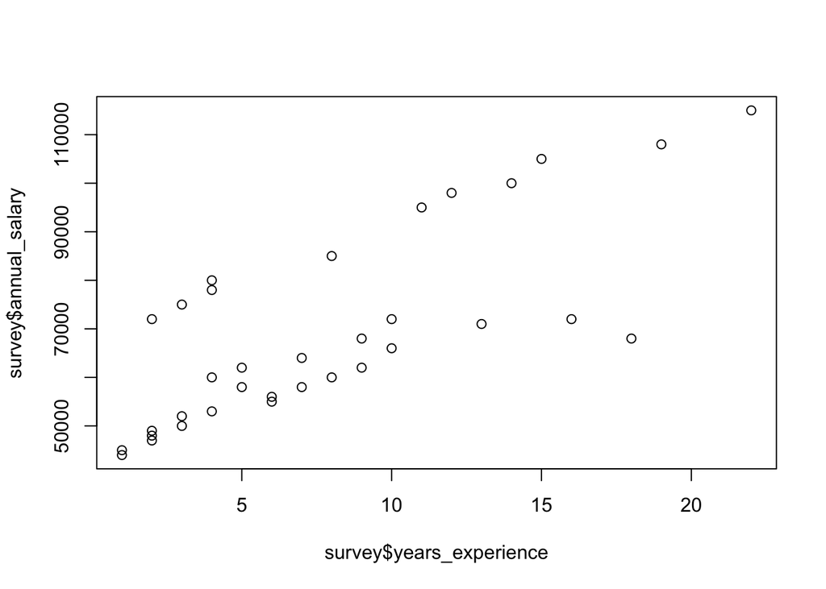

```r
# Basic scatter plot (two quantitative varaibales)
plot(survey$years_experience, survey$annual_salary)
```

That works, but it’s ugly. Let’s add labels, color, and a trend line.

```r
# Color points by department

unique(survey$department)
```

```
[1] "Marketing"   "Engineering" "Sales"       "HR"          "Unknown"
```

```r
dept_colors <- c(
  Engineering = "steelblue",
  HR = "tomato",
  Marketing = "forestgreen",
  Sales = "darkorange",
  Unknown = "gray50"
)

colors() # all named colors
```

```
  [1] "white"                "aliceblue"            "antiquewhite"
  [4] "antiquewhite1"        "antiquewhite2"        "antiquewhite3"
  [7] "antiquewhite4"        "aquamarine"           "aquamarine1"
 [10] "aquamarine2"          "aquamarine3"          "aquamarine4"
 [13] "azure"                "azure1"               "azure2"
 [16] "azure3"               "azure4"               "beige"
 [19] "bisque"               "bisque1"              "bisque2"
 [22] "bisque3"              "bisque4"              "black"
 [25] "blanchedalmond"       "blue"                 "blue1"
 [28] "blue2"                "blue3"                "blue4"
 [31] "blueviolet"           "brown"                "brown1"
 [34] "brown2"               "brown3"               "brown4"
 [37] "burlywood"            "burlywood1"           "burlywood2"
 [40] "burlywood3"           "burlywood4"           "cadetblue"
 [43] "cadetblue1"           "cadetblue2"           "cadetblue3"
```

[output cut: 204 more lines]

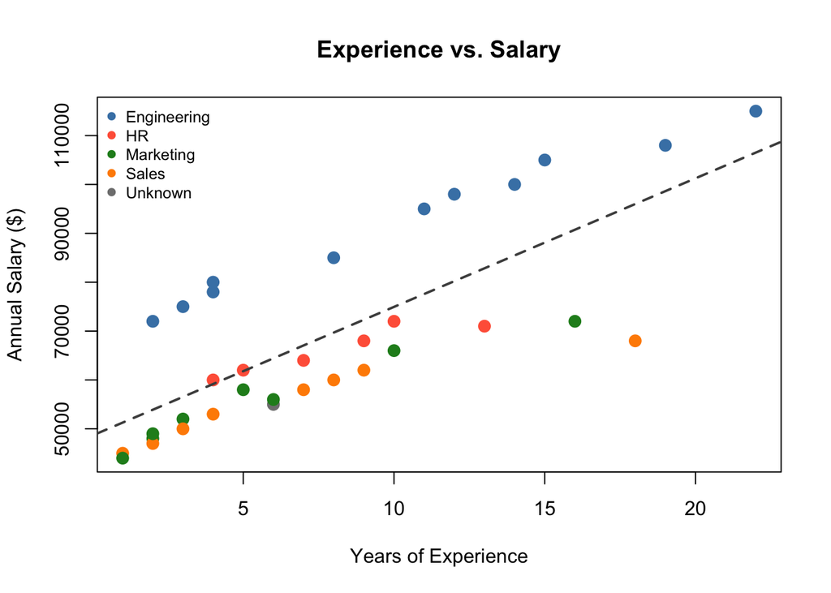

```r
point_cols <- dept_colors[survey$department]
# It looks at each department in survey$department, matches it to the corresponding named color in dept_colors, and returns a color vector in the same row order as survey.

# Create a scatter plot of annual salary against years of experience.
# Each point is colored according to department using point_cols.
# pch = 19 uses solid circles, and cex = 1.3 makes the points slightly larger.
# xlab and ylab set the axis labels, and main adds the plot title.

plot(
  survey$years_experience, survey$annual_salary,
  col = point_cols,
  pch = 19, # solid circles (pch = 19)
  cex = 1.3, # point size
  xlab = "Years of Experience",
  ylab = "Annual Salary ($)",
  main = "Experience vs. Salary"
)

# Common ones:
# pch = 1: open circle
# pch = 15: filled square
# pch = 16: filled circle
# pch = 17: filled triangle
# pch = 19: solid circle

# Add a trend line
abline(
  lm(annual_salary ~ years_experience, data = survey),
  lty = 2, col = "gray30", lwd = 2
)

# lty = 1: solid line
# lty = 2: dashed line
# lty = 3: dotted line
# lty = 4: dot-dash line
# lty = 5: long-dash line
# lty = 6: two-dash line

# Add a legend
legend("topleft",
       legend = names(dept_colors),
       col    = dept_colors,
       pch    = 19,
       cex    = 0.8,
       bty    = "n")          # no legend box
```

```r
# Common bty values:
# bty = "o": full box around the plot
# bty = "l": only left and bottom lines
# bty = "7": top and right removed
# bty = "c": left removed
# bty = "u": top removed
# bty = "]": left and top removed
# bty = "n": no box
```

**Tip**

Key arguments for `plot()` `pch` = point shape (19 = solid circle), `cex` = size multiplier, `col` = color, `lwd` = line width, `lty` = line type (1 = solid, 2 = dashed).

### 5.1.2 Histogram — `hist()`

Shows how a single numeric variable is distributed.

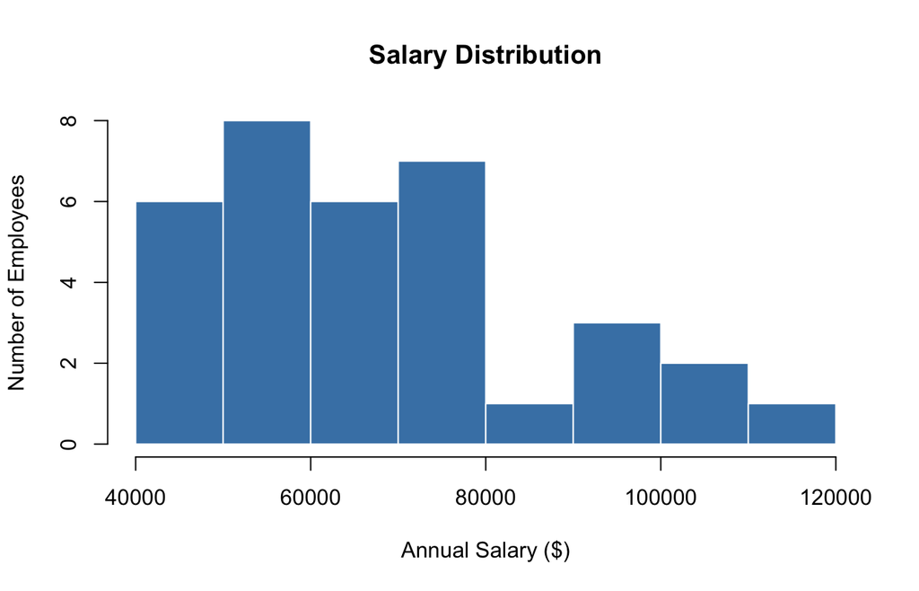

```r
hist(survey$annual_salary,
     breaks = 8,                         # number of bins
     col    = "steelblue",
     border = "white",
     main   = "Salary Distribution",
     xlab   = "Annual Salary ($)",
     ylab   = "Number of Employees")
```

**Tip**

Choosing `breaks` `breaks` controls how many bins. More bins = more detail but noisier. Try `breaks = 5`, then `breaks = 15`, and see what tells the clearest story.

### 5.1.3 Box Plot — `boxplot()`

Compares the distribution of a number across groups (Quantitative vs Categorical).

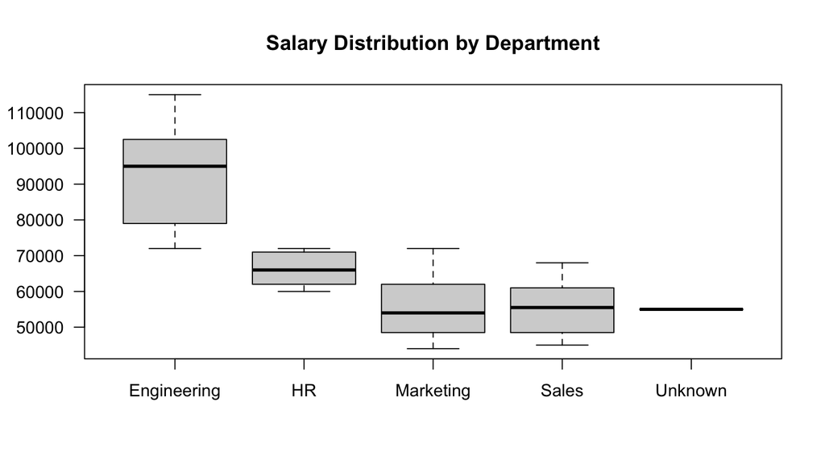

```r
boxplot(annual_salary ~ department,
        data = survey,
        # col  = c("steelblue", "tomato", "forestgreen",
        #          "darkorange", "gray80"),
        main = "Salary Distribution by Department",
        xlab = "",
        ylab = "",
        las  = 1)                        # horizontal y-axis labels
```

The box is the middle 50% (IQR). The thick line is the median. Dots beyond the whiskers are potential outliers.

### 5.1.4 Bar Plot — `barplot()`

Shows counts or pre-calculated values as bars.

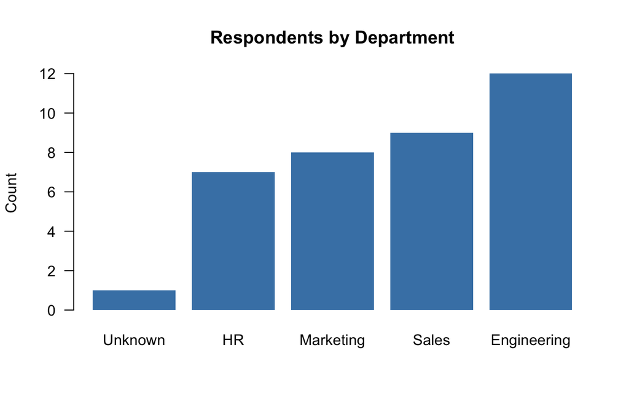

```r
# Count respondents per department
dept_counts <- table(survey$department)

barplot(sort(dept_counts),
        col      = "steelblue",
        main     = "Respondents by Department",
        ylab     = "Count",
        las      = 1,
        border   = NA)                  # cleaner look without borders
```

For **pre-calculated values** (like averages), compute first then plot:

[figure not shown]

```r
# Average salary by department
avg_sal <- tapply(survey$annual_salary, survey$department, mean)
avg_sal <- sort(avg_sal)

# Horizontal bar plot
barplot(avg_sal,
        horiz  = TRUE,
        col    = "steelblue",
        main   = "Average Salary by Department",
        xlab   = "Average Annual Salary ($)",
        las    = 1,
        border = NA)
```

**Tip**

`table()` and `tapply()` — your bar plot friends `table(x)` counts how many of each value. `tapply(value, group, function)` applies a function (like `mean`) to each group — perfect for feeding into `barplot()`.

## 5.2 Polish Your Plots

### 5.2.1 Titles and Labels

Every base R plot function accepts these arguments:

| Argument | What it does | Example |
| --- | --- | --- |
| `main` | Title above the plot | `main = "My Title"` |
| `sub` | Subtitle below the plot | `sub = "Source: survey"` |
| `xlab` | X-axis label | `xlab = "Age"` |
| `ylab` | Y-axis label | `ylab = "Salary ($)"` |

### 5.2.2 Colors

You can use color names (`"steelblue"`, `"tomato"`) or hex codes (`"#2C73D2"`). Run `colors()` in R to see all 657 built-in color names.

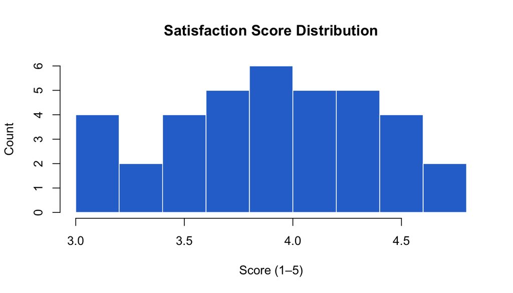

```r
hist(survey$satisfaction_score,
     breaks = 10,
     col    = "#2C73D2",
     border = "white",
     main   = "Satisfaction Score Distribution",
     xlab   = "Score (1–5)",
     ylab   = "Count")
```

### 5.2.3 Adding Extra Elements

[figure not shown]

```r
plot(survey$age, survey$annual_salary,
     pch  = 19,
     col  = "steelblue",
     cex  = 1.2,
     xlab = "Age",
     ylab = "Annual Salary ($)",
     main = "Age vs. Salary")

# Trend line
abline(lm(annual_salary ~ age, data = survey),
       col = "tomato", lwd = 2, lty = 2)

# Horizontal reference line at the mean salary
abline(h = mean(survey$annual_salary),
       col = "gray50", lty = 3)

# Label the reference line
text(x = 26, y = mean(survey$annual_salary) + 2500,
     labels = paste("Mean:", round(mean(survey$annual_salary))),
     cex = 0.8, col = "gray40")

# Add a grid for readability
grid(col = "gray90")
```

#### 5.2.3.1 Multi-Panel Layouts

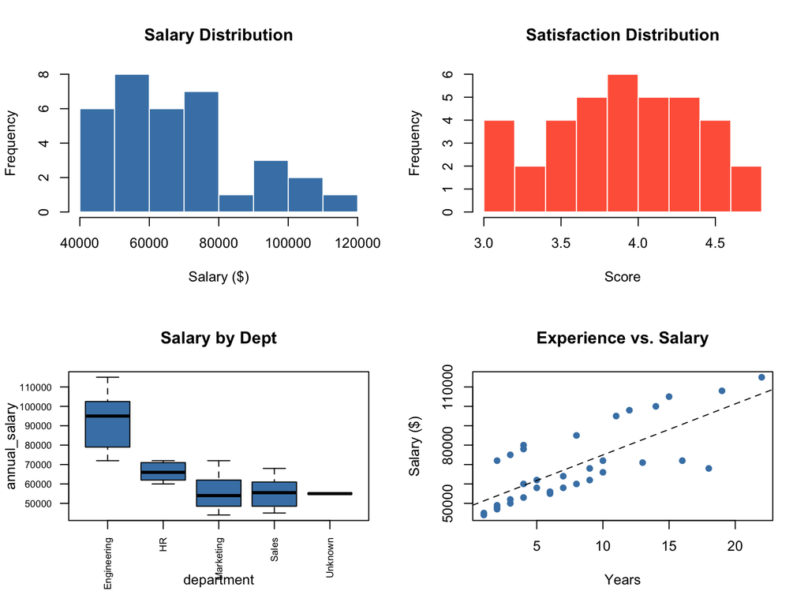

```r
par(mfrow = c(2, 2))   # 2 rows, 2 columns

hist(survey$annual_salary, col = "steelblue", border = "white",
     main = "Salary Distribution", xlab = "Salary ($)")

hist(survey$satisfaction_score, col = "tomato", border = "white",
     main = "Satisfaction Distribution", xlab = "Score")

boxplot(annual_salary ~ department, data = survey,
        col = "steelblue", main = "Salary by Dept", las = 2, cex.axis = 0.7)

plot(survey$years_experience, survey$annual_salary,
     pch = 19, col = "steelblue", cex = 0.9,
     main = "Experience vs. Salary", xlab = "Years", ylab = "Salary ($)")
abline(lm(annual_salary ~ years_experience, data = survey), lty = 2)
```

```r
par(mfrow = c(1, 1))   # reset to single panel
```

## 5.3 Saving Plots

```r
getwd()

# Simplest method: Using the "Plots" tab to export plots

# Save to PNG
png("salary_scatter.png", width = 700, height = 450, res = 150)
plot(survey$years_experience, survey$annual_salary,
     pch = 19, col = "steelblue",
     xlab = "Experience", ylab = "Salary",
     main = "Experience vs. Salary")
abline(lm(annual_salary ~ years_experience, data = survey), lty = 2)
dev.off()   # IMPORTANT: closes the file

# You do not need an existing PNG file first. `png()` creates a new image file, and the plot is saved into it when `dev.off()` is called.

# Save to PDF (great for publications)
pdf("salary_scatter.pdf", width = 7, height = 4.5)
# ... same plot code ...
dev.off()
```

**Warning**

Don’t forget `dev.off()`! When saving to a file, you must call `dev.off()` after your plot code. Otherwise the file won’t be written and your plots will stop showing up in RStudio.

## 5.4 Cheat Sheet

### 5.4.1 Which Function Do I Need?

| Question | Function | Example |
| --- | --- | --- |
| How do two numbers relate? | `plot(x, y)` | `plot(age, salary)` |
| How is a number distributed? | `hist(x)` | `hist(salary)` |
| How do groups compare? | `boxplot(y ~ group)` | `boxplot(salary ~ dept)` |
| How many per group? | `barplot(table(x))` | `barplot(table(dept))` |
| What’s the average per group? | `barplot(tapply(...))` | `barplot(tapply(sal, dept, mean))` |

### 5.4.2 Common Appearance Arguments

| Argument | Controls | Values |
| --- | --- | --- |
| `col` | Fill color | `"steelblue"`, `"#FF6347"`, `c("red","blue")` |
| `border` | Border color | `"white"`, `NA` (no border) |
| `pch` | Point shape | 19 = solid circle, 1 = open circle, 17 = triangle |
| `cex` | Size multiplier | 1 = default, 1.5 = 50% bigger |
| `lwd` | Line width | 1 = default, 2 = double |
| `lty` | Line type | 1 = solid, 2 = dashed, 3 = dotted |
| `las` | Axis label direction | 1 = horizontal, 2 = perpendicular |

### 5.4.3 Adding Extras to a Plot

| Function | What it adds |
| --- | --- |
| `abline(lm(...))` | Trend line |
| `abline(h = value)` | Horizontal line |
| `abline(v = value)` | Vertical line |
| `legend(...)` | Legend |
| `text(x, y, label)` | Text label at a point |
| `grid()` | Grid lines |
| `points(x, y)` | More points on top |
| `lines(x, y)` | Lines on top |

# 6 Module 6: Leveraging AI Tools

## 6.1 Learning Objectives

- Understand how generative AI can assist your R workflow
- Learn effective prompting strategies for R code generation
- Use AI to debug errors and understand code
- Know the limitations and best practices

## 6.2 How AI Can Help You Learn R

### 6.2.1 1. Writing Code from Natural Language

You can describe what you want to accomplish in plain English, and AI tools can generate the R code for you.

**Example prompt:**

> “Using the mpg dataset in R with the tidyverse, create a bar chart showing the average highway mpg for each car class, sorted from highest to lowest, with a clean minimal theme.”

**What you might get back:**

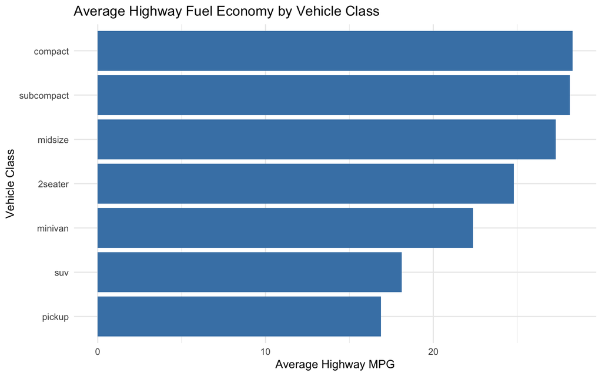

```r
mpg |>
  group_by(class) |>
  summarize(avg_hwy = mean(hwy)) |>
  ggplot(aes(x = reorder(class, avg_hwy), y = avg_hwy)) +
  geom_col(fill = "steelblue") +
  coord_flip() +
  labs(x = "Vehicle Class", y = "Average Highway MPG",
       title = "Average Highway Fuel Economy by Vehicle Class") +
  theme_minimal()
```

### 6.2.2 2. Debugging Error Messages

When you get an error, you can paste it into an AI tool and ask for help.

**Example:** “I’m getting this error in R. What does it mean and how do I fix it?”

```
Error in select(., name, height) :
  unused arguments (name, height)
```

**AI would explain:** This typically happens when another package (like MASS) has overwritten dplyr’s `select()`. Fix it by being explicit: `dplyr::select()`.

### 6.2.3 3. Explaining Code

Paste code you don’t understand and ask AI to explain it line by line.

### 6.2.4 4. Discovering New Methods

Ask AI things like:

- “What’s the best way to remove duplicate rows in R?”
- “How do I join two datasets in the tidyverse?”
- “What alternatives exist for creating interactive plots in R?”

## 6.3 Tips for Effective AI Prompting for R

### 6.3.1 Be Specific About Your Data

```r
# BAD prompt:  "Make a plot of my data"
# GOOD prompt: "Using ggplot2, create a scatter plot of the mpg dataset
#               with displ on the x-axis and hwy on the y-axis,
#               colored by the drv variable, with a smooth trend line."
```

### 6.3.2 Include Context

Tell the AI:

- What packages you’re using (tidyverse, specific packages)
- What your data looks like (column names, types, sample rows)
- What you’ve already tried
- What output format you want

### 6.3.3 Ask for Explanations

Add “and explain each step” to your prompts to learn while coding.

### 6.3.4 Iterate

Start with a basic request, then refine: “Now change the colors to a blue-to-red gradient” or “Add error bars.”

## 6.4 Practical AI Exercise

```r
# Try these prompts with your AI tool of choice (ChatGPT, Claude, etc.):

# 1. "Write tidyverse code to find the top 5 most expensive diamond cuts
#     in the diamonds dataset, showing average price and count."

# 2. Paste this buggy code and ask AI to fix it:
#    mpg %>%
#      filter(class = "suv") %>%
#      sumamrize(mean_hwy == mean(hwy))

# 3. Ask: "Explain what the following code does step by step:"
#    diamonds |>
#      filter(carat > 1) |>
#      group_by(cut, color) |>
#      summarize(avg_price = mean(price), .groups = "drop") |>
#      pivot_wider(names_from = color, values_from = avg_price)
```

## 6.5 Best Practices and Caveats

1. **Always test AI-generated code** — Run it yourself and verify it works
2. **Understand what the code does** — Don’t just copy-paste blindly
3. **AI can make mistakes** — Especially with newer packages or niche functions
4. **Use AI as a learning accelerator** — Not a replacement for understanding
5. **Start simple, build up** — Ask for basic code first, then add complexity
6. **Cross-reference with documentation** — Use `?function_name` in R for official docs

# 7 Additional: Data Visualization with ggplot2

## 7.1 Learning Objectives

- Understand the grammar of graphics (data + aesthetics + geometries)
- Create common plot types: scatter, bar, line, histogram, box plot
- Customize colors, labels, and themes
- Save plots to files

## 7.2 Key Concepts

### 7.2.1 The Grammar of Graphics

Every ggplot has three essential components:

1. **Data** — the dataset
2. **Aesthetics** (`aes()`) — what variables map to x, y, color, size, etc.
3. **Geometries** (`geom_*()`) — how to draw the data (points, bars, lines, etc.)

### 7.2.2 Scatter Plots

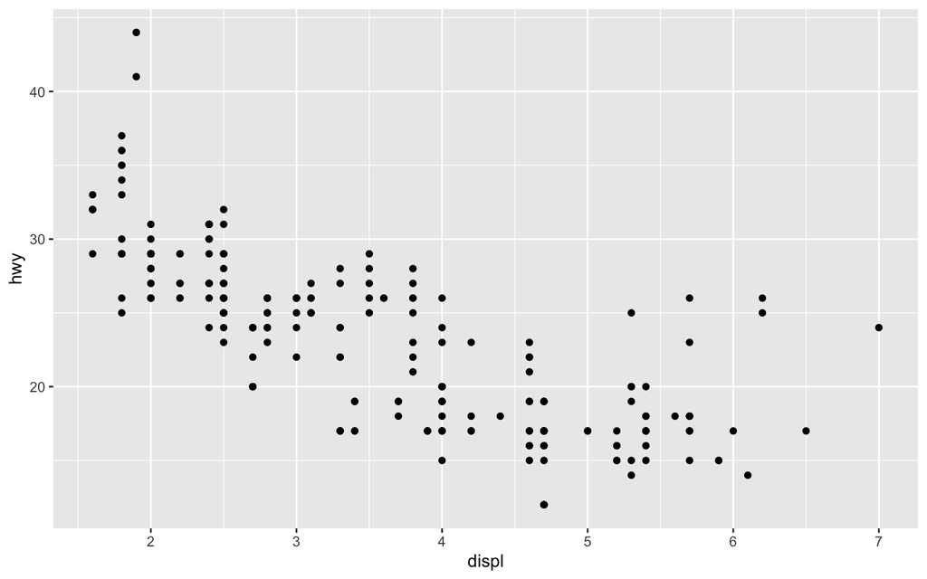

```r
# Basic scatter plot
ggplot(data = mpg, aes(x = displ, y = hwy)) +
  geom_point()
```

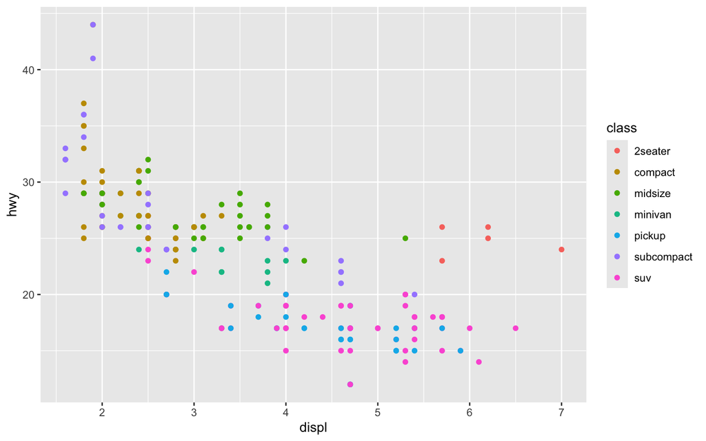

```r
# Add color by a variable
ggplot(mpg, aes(x = displ, y = hwy, color = class)) +
  geom_point()
```

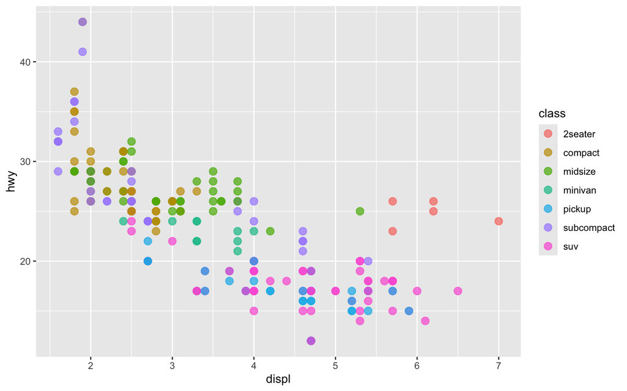

```r
# Add size and transparency
ggplot(mpg, aes(x = displ, y = hwy, color = class)) +
  geom_point(size = 3, alpha = 0.7)
```

### 7.2.3 Bar Charts

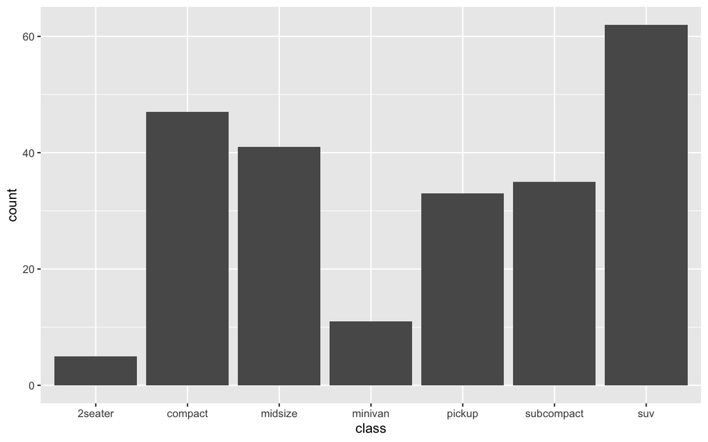

```r
# Count-based bar chart (the default)
ggplot(mpg, aes(x = class)) +
  geom_bar()
```

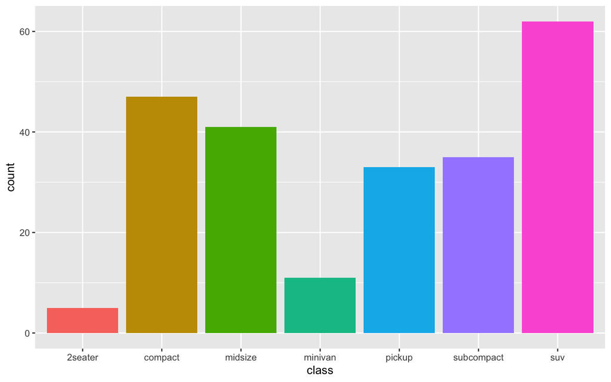

```r
# Colored bars
ggplot(mpg, aes(x = class, fill = class)) +
  geom_bar() +
  theme(legend.position = "none")
```

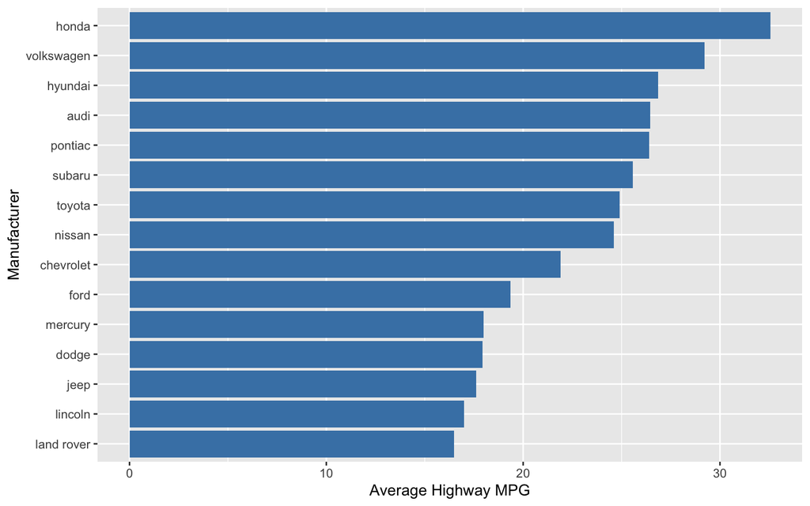

```r
# Bar chart with a pre-calculated value
mpg |>
  group_by(manufacturer) |>
  summarize(avg_hwy = mean(hwy)) |>
  ggplot(aes(x = reorder(manufacturer, avg_hwy), y = avg_hwy)) +
  geom_col(fill = "steelblue") +
  coord_flip() +
  labs(x = "Manufacturer", y = "Average Highway MPG")
```

### 7.2.4 Histograms and Density Plots

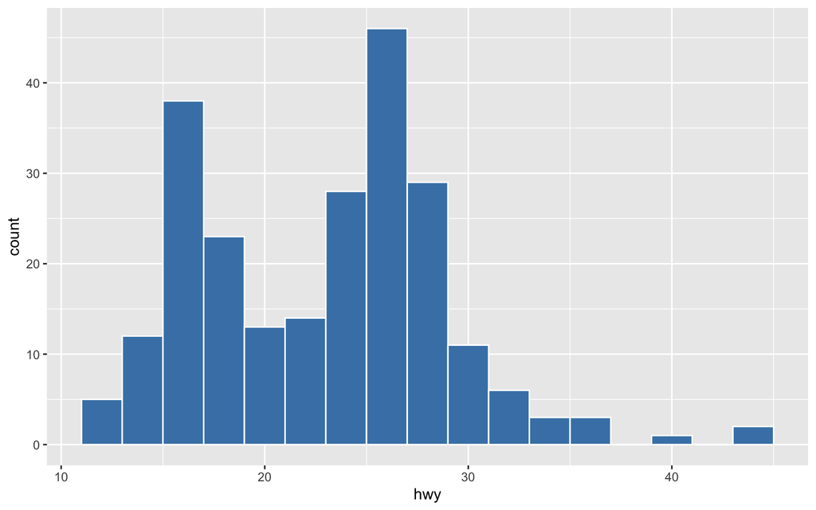

```r
# Histogram
ggplot(mpg, aes(x = hwy)) +
  geom_histogram(binwidth = 2, fill = "steelblue", color = "white")
```

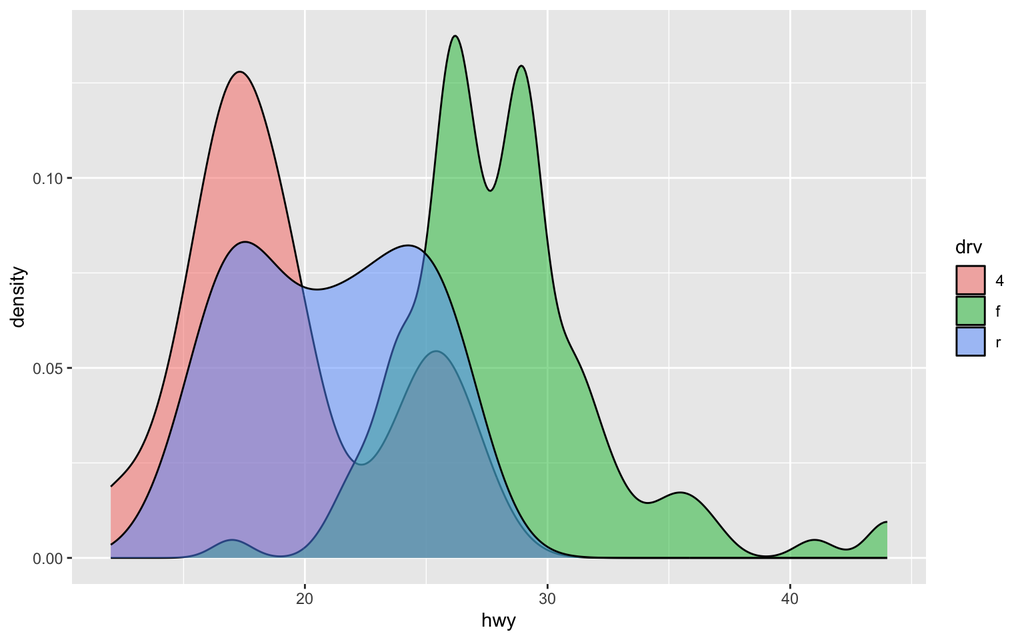

```r
# Density plot
ggplot(mpg, aes(x = hwy, fill = drv)) +
  geom_density(alpha = 0.5)
```

### 7.2.5 Box Plots

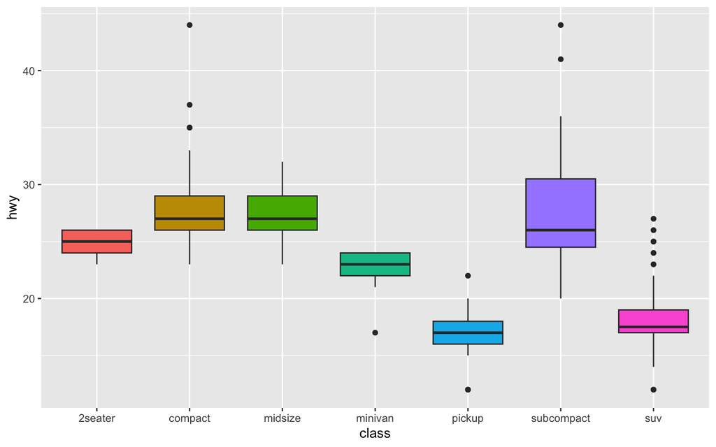

```r
# Box plot comparing groups
ggplot(mpg, aes(x = class, y = hwy, fill = class)) +
  geom_boxplot() +
  theme(legend.position = "none")
```

### 7.2.6 Line Charts

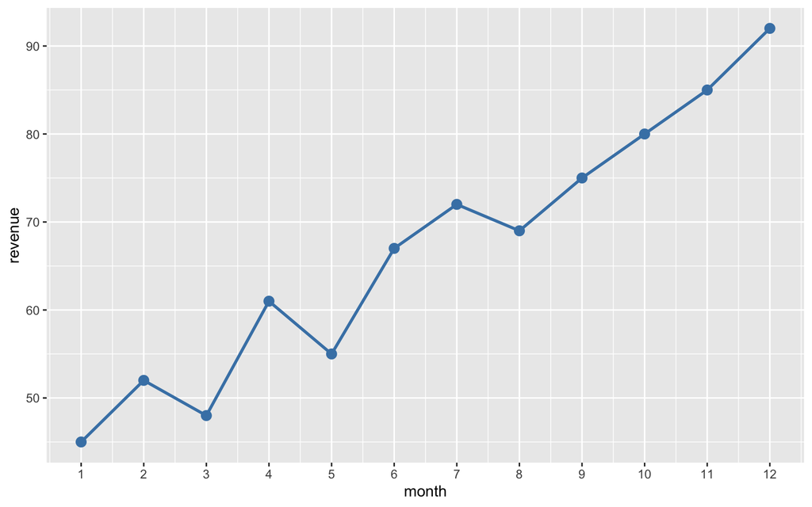

```r
# Create some time series data
monthly_sales <- tibble(
  month = 1:12,
  revenue = c(45, 52, 48, 61, 55, 67, 72, 69, 75, 80, 85, 92)
)

ggplot(monthly_sales, aes(x = month, y = revenue)) +
  geom_line(color = "steelblue", linewidth = 1) +
  geom_point(color = "steelblue", size = 3) +
  scale_x_continuous(breaks = 1:12)
```

### 7.2.7 Adding Labels and Themes

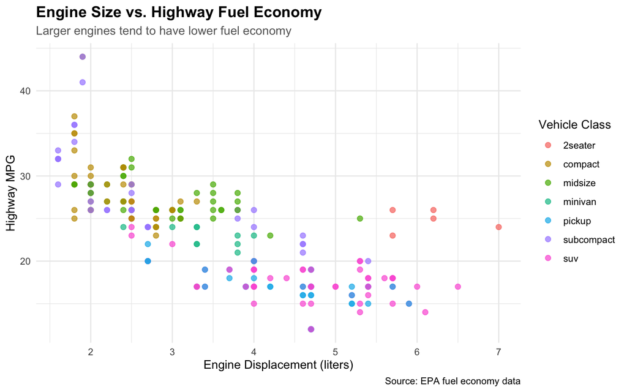

```r
ggplot(mpg, aes(x = displ, y = hwy, color = class)) +
  geom_point(size = 2, alpha = 0.7) +
  labs(
    title = "Engine Size vs. Highway Fuel Economy",
    subtitle = "Larger engines tend to have lower fuel economy",
    x = "Engine Displacement (liters)",
    y = "Highway MPG",
    color = "Vehicle Class",
    caption = "Source: EPA fuel economy data"
  ) +
  theme_minimal() +
  theme(
    plot.title = element_text(face = "bold", size = 14),
    plot.subtitle = element_text(color = "gray40")
  )
```

### 7.2.8 Facets — Small Multiples

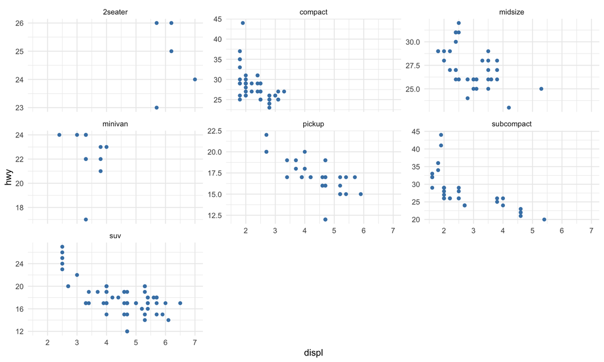

```r
# Split into panels by a variable
ggplot(mpg, aes(x = displ, y = hwy)) +
  geom_point(color = "steelblue") +
  facet_wrap(~ class, scales = "free_y") +
  theme_minimal()
```

### 7.2.9 Saving Plots

```r
# Save the last plot you created
ggsave("my_plot.png", width = 8, height = 5, dpi = 300)

# Save a specific plot
my_plot <- ggplot(mpg, aes(x = displ, y = hwy)) + geom_point()
ggsave("scatter.pdf", plot = my_plot, width = 8, height = 5)
```

# 8 Addtional: R Packages (Three Common Live Places)

Not everything is on CRAN. Here’s where to look:

| Source | What’s there | How to install |
| --- | --- | --- |
| **CRAN** | ~20,000 general-purpose packages | `install.packages("name")` |
| **Bioconductor** | ~2,200 packages for genomics, genetics, bioinformatics | `BiocManager::install("name")` |
| **GitHub** | Development versions, niche tools, unreleased packages | `devtools::install_github("user/repo")` |

## 8.1 CRAN — The Default

```r
# Most packages you'll encounter
install.packages("tidyverse")
install.packages("ape")          # phylogenetics & population genetics

library(ape)
```

If `install.packages()` works, you’re on CRAN. Nothing else needed.

## 8.2 Bioconductor — Genetics & Genomics

Many genetics and bioinformatics packages live on [Bioconductor](https://bioconductor.org/), not CRAN. You need `BiocManager` to install them.

```r
# Step 1: Install BiocManager (one time, from CRAN)
install.packages("BiocManager")

# Step 2: Use it to install Bioconductor packages
BiocManager::install("Biostrings")        # DNA/RNA sequence handling
BiocManager::install("VariantAnnotation") # VCF files & variant data
BiocManager::install("GenomicRanges")     # genomic intervals
BiocManager::install("DESeq2")            # differential gene expression

# Then load normally
library(Biostrings)
```

**Tip**

Finding Bioconductor packages Browse [bioconductor.org/packages](https://bioconductor.org/packages/release/BiocViews.html#___Software) or search by topic (e.g., “Genetics”, “Sequencing”, “Variant”). Each package page has install instructions.

## 8.3 GitHub — devtools / remotes

Some packages aren’t on CRAN or Bioconductor at all — they only exist on GitHub. Others have a development version on GitHub that’s newer than the CRAN release.

```r
# Step 1: Install devtools or remotes (one time)
install.packages("devtools")
# or the lighter alternative:
install.packages("remotes")

# Step 2: Install from GitHub using "username/repository"
devtools::install_github("tidyverse/dplyr")          # dev version of dplyr
remotes::install_github("YuLab-SMU/ggtree")          # phylogenetic tree plots


# Then load normally
library(ggtree)
```

**Note**

`devtools` vs `remotes` `remotes` does just the installation part and is faster to install. `devtools` includes `remotes` plus tools for *building your own* packages. For just installing other people’s packages, either works — `remotes` is lighter.

## 8.4 Quick Decision Guide

```
Need a package?
│
├─ Try install.packages("name") first
│   └─ Works? → Done!
│
├─ "Package not available" error?
│   ├─ Is it a bio/genetics package? → BiocManager::install("name")
│   └─ Is it on GitHub? → devtools::install_github("user/repo")
│
└─ Still can't find it?
    └─ Search: google "R package [what you need]"
       or ask AI: "What R package does [task]?"
```

## 8.5 Common Genetics / Bioinformatics Packages

| Package | Source | What it does |
| --- | --- | --- |
| `ape` | CRAN | Phylogenetics, population genetics |
| `pegas` | CRAN | Population & evolutionary genetics |
| `adegenet` | CRAN | Multivariate genetics (PCA, DAPC) |
| `Biostrings` | Bioconductor | DNA/RNA/protein sequence manipulation |
| `GenomicRanges` | Bioconductor | Genomic intervals and annotations |
| `DESeq2` | Bioconductor | Differential gene expression (RNA-seq) |
| `VariantAnnotation` | Bioconductor | Read and annotate VCF files |
| `SNPRelate` | Bioconductor | SNP data analysis (PCA, relatedness) |
| `ggtree` | GitHub / Bioconductor | Phylogenetic tree visualization |